# Decision Analysis - Project 3

- **Mateusz Tabaszewski 151945**
- **Bartłomiej Pukacki 151942**

## Installs and Imports

```python
# !pip uninstall scikit-learn -y
# !pip install scikit-learn==1.1.3
!pip install shap
!pip install captum
```

```python
import warnings
warnings.filterwarnings("ignore")
```

```python
import numpy as np
import pandas as pd
import matplotlib.pyplot as plt
from sklearn.linear_model import LogisticRegression
from sklearn.metrics import accuracy_score, f1_score, roc_auc_score
from sklearn.base import BaseEstimator, ClassifierMixin
import torch
import torch.nn as nn
import torch.optim as optim
from torch.utils.data import DataLoader, TensorDataset
from sklearn.model_selection import train_test_split
import torch.nn.functional as F
import random
import os
import warnings
import shap
from sklearn.linear_model import LogisticRegression
from sklearn.inspection import PartialDependenceDisplay, partial_dependence, plot_partial_dependence


from captum.attr import IntegratedGradients, DeepLift, GradientShap, NoiseTunnel, FeatureAblation, GuidedBackprop
```

```python
def set_all_seeds(seed):
    os.environ['PYTHONHASHSEED'] = str(seed)
    random.seed(seed)
    np.random.seed(seed)
    torch.manual_seed(seed)
    torch.cuda.manual_seed(seed)
    torch.backends.cudnn.deterministic = True
```

```python
set_all_seeds(42)
```

## Functions, Models and Utilities

### Utils

```python
def plot_columns(df, figsize = (12, 8), color="grey"):
    num_cols = len(df.columns)
    num_rows = (num_cols + 1) // 2
    fig, axes = plt.subplots(num_rows, 2, figsize=figsize)
    if num_rows == 1:
        axes = axes.reshape(1, -1)
    for i, column in enumerate(df.columns):
        ax = axes[i // 2, i % 2]
        df[column].plot(kind='hist', ax=ax, title=column, color=color)
        ax.set_title(f"Distribution for {column}")
        ax.set_xlabel('Value')
        ax.set_ylabel('Frequency')
    fig.suptitle("Data Distribution Plot")
    plt.tight_layout()
    plt.show()
```

```python
def plot_stats(accuracy, test_accuracy, f1, f1_test, auc, auc_test):
    fig, axes = plt.subplots(1, 3, figsize=(12, 5))
    color = 'grey'
    axes[0].bar(['Train', 'Test'], [accuracy, test_accuracy], color=color)
    axes[0].axhline(y=0.5, color='red', linestyle='--', label='Random Guess')
    axes[0].set_title('Accuracy')
    axes[0].legend()
    axes[0].set_ylim(0, 1)
    axes[1].bar(['Train', 'Test'], [f1, f1_test], color=color)
    axes[1].set_title('F1 Score')
    axes[1].set_ylim(0, 1)
    axes[2].bar(['Train', 'Test'], [auc, auc_test], color=color)
    axes[2].set_title('AUC')
    axes[2].set_ylim(0, 1)
    plt.tight_layout()
    plt.show()
```

```python
def use_model(model, X_train, y_train, X_test, y_test):
    model.fit(X_train, y_train)
    y_preds = model.predict(X_train)
    accuracy = round(accuracy_score(y_train, y_preds), 4)
    f1 = round(f1_score(y_train, y_preds), 4)
    y_preds_positive = model.predict_proba(X_train)[:, 1]
    auc = round(roc_auc_score(y_train, y_preds_positive), 4)

    y_preds = model.predict(X_test)
    accuracy_test = round(accuracy_score(y_test, y_preds), 4)
    f1_test = round(f1_score(y_test, y_preds), 4)
    y_preds_positive = model.predict_proba(X_test)[:, 1]
    auc_test = round(roc_auc_score(y_test, y_preds_positive), 4)
    return model, accuracy, f1, auc, accuracy_test, f1_test, auc_test
```

```python
def get_logistic_regression_changed_prediction(test_example, columns, coefficients, intercept, classifier):
    sum= 0.0
    epsilon = 1e-3
    example_list = list(test_example)
    zipped_lists = zip(coefficients, example_list, range(len(coefficients)))
    sorted_lists = sorted(zipped_lists, reverse=True)
    sorted_coeffs, example_list, original_order = zip(*sorted_lists)
    example_list = list(example_list)
    original_order = list(original_order)
    sorted_coeffs = list(sorted_coeffs)

    for i in range(len(example_list)):
        sum += example_list[i]*sorted_coeffs[i]
    sum += intercept
    prev_examples = example_list.copy()
    if sum>=0:
        for i in range(len(example_list)):
            val = -1*intercept-epsilon
            for j in range(len(example_list)):
                if i != j:
                    val -= example_list[j]*sorted_coeffs[j]
            example_list[i] = val/sorted_coeffs[i]
            if example_list[i]<0:
                example_list[i] = 0
            elif example_list[i]>1:
                example_list[i] = 1
            else:
                break
    else:
        for i in range(len(example_list)):
            val = -1*intercept+epsilon
            for j in range(len(example_list)):
                if i != j:
                    val -= example_list[j]*sorted_coeffs[j]
            example_list[i] = val/sorted_coeffs[i]
            if example_list[i]<0:
                example_list[i] = 0
            elif example_list[i]>1:
                example_list[i] = 1
            else:
                break

    original_order = [original_order.index(i) for i in range(len(original_order))]
    example_list = [example_list[i] for i in original_order]
    prev_examples = [prev_examples[i] for i in original_order]
    rounded_examples = [round(example, 4) for example in example_list]
    rounded_prevs = [round(example, 4) for example in prev_examples]
    differences = list(np.array(prev_examples) - np.array(example_list))
    differences = [round(diff, 4) for diff in differences]
    print(f"Columns in order: {columns}")
    print(f"Original Example: {rounded_prevs}")
    print(f"New Example Assigned to a different class: {rounded_examples}")
    print(f"Minimal Differences: {differences}")
    print(f"Model's original decision {classifier.predict([prev_examples])}")
    print(f"Model's new decision: {classifier.predict([example_list])}")
```

```python
def change_class_by_sampling(test_example, columns, coefficients, classifier, epsilon=1e-3):
    example_list = list(test_example)
    prev_examples = example_list.copy()
    original_class = classifier.predict([example_list])[0]
    i=0
    while True:
        zipped_lists = zip(coefficients, example_list, range(len(coefficients)))
        sorted_lists = sorted(zipped_lists, reverse=True)
        sorted_coeffs, example_list, original_order = zip(*sorted_lists)
        example_list = list(example_list)
        original_order = list(original_order)
        sorted_coeffs = list(sorted_coeffs)
        if original_class == 1:
            example_list[i] -= epsilon
        else:
            example_list[i] += epsilon
        if example_list[i]<=0:
            example_list[i] = 0
            i+=1
        elif example_list[i]>=1:
            example_list[i] = 1
            i+=1
        original_order = [original_order.index(i) for i in range(len(original_order))]
        example_list = [example_list[i] for i in original_order]
        new_class = classifier.predict([example_list])[0]
        if new_class != original_class:
            break

    rounded_examples = [round(example, 4) for example in example_list]
    rounded_prevs = [round(example, 4) for example in prev_examples]
    differences = list(np.array(prev_examples) - np.array(example_list))
    differences = [round(diff, 4) for diff in differences]
    print(f"Columns in order: {columns}")
    print(f"Original Example: {rounded_prevs}")
    print(f"New Example Assigned to a different class: {rounded_examples}")
    print(f"Minimal Differences: {differences}")
    print(f"Model's original decision {original_class}")
    print(f"Model's new decision: {new_class}")

def nn_change_class_by_sampling(test_example, columns, classifier, epsilon=1e-3):
    example_list = list(test_example)
    original_class = int(classifier.predict([example_list])[0])

    best_new_example = None
    best_new_class = None
    best_difference = None

    min_change = float('inf')
    for i, criterion in enumerate(columns):
        # print(criterion)
        new_example = example_list.copy()
        new_class = int(classifier.predict([example_list])[0])

        while new_class == original_class and (new_example[i] <= 1 and new_example[i] >= 0):
            new_class = int(classifier.predict([new_example])[0])
            # print(new_example)
            if new_class != original_class:
                difference = np.array(example_list) - np.array(new_example)
                if abs(difference[i]) < min_change:
                    min_change = difference[i]
                    best_difference = difference.copy()
                    best_new_example = new_example.copy()
                    best_new_class = new_class

            if original_class == 1:
                new_example[i] -= epsilon
            else:
                new_example[i] += epsilon

    for i, criterion1 in enumerate(columns):
        for j, criterion2 in enumerate(columns[i+1:], start=i+1):
            # print(f"Combination: {criterion1}, {criterion2}")
            new_example = example_list.copy()
            new_class = int(classifier.predict([new_example])[0])

            while new_class == original_class and (new_example[i] <= 1 and new_example[i] >= 0):
                new_class = int(classifier.predict([new_example])[0])
                # print(new_example)
                if new_class != original_class:
                    difference = np.array(example_list) - np.array(new_example)
                    if abs(difference[i] + difference[j]) < min_change:
                        min_change = difference[i] + difference[j]
                        best_difference = difference.copy()
                        best_new_example = new_example.copy()
                        best_new_class = new_class

                if original_class == 1:
                    new_example[i] -= epsilon
                    new_example[j] -= epsilon
                else:
                    new_example[i] += epsilon
                    new_example[j] -= epsilon

    rounded_prevs = [round(example, 4) for example in example_list]
    rounded_new = [round(example, 4) for example in best_new_example]
    print(f"Columns in order: {columns}")
    print(f"Original Example: {rounded_prevs}")
    print(f"New Example Assigned to a different class: {rounded_new}")
    print(f"Differences: {best_difference}")
    print(f"Model's original decision {original_class}")
    print(f"Model's new decision: {best_new_class}")
```

```python
def calculate_smallest_change_MCDA(test_example, columns, combined_weights, neural_MCDA_compatible, threshold, most_influential_column = "BI-RADS", skip_cols = []):
    original_class = neural_MCDA_compatible.predict([test_example])[0]
    if original_class == 0:
        epsilon = 1e-3
    else:
        epsilon = -1e-3
    target_weights = [combined_weights[i] for i in range(len(columns)) if (most_influential_column in columns[i] and not any(skip_col in columns[i] for skip_col in skip_cols))]
    test_example_copy = test_example.copy()
    test_example_copy = [0 if (most_influential_column in columns[i] and not any(skip_col in columns[i] for skip_col in skip_cols)) else test_example[i] for i in range(len(columns))]
    value = epsilon
    value += (threshold) - np.sum(np.array(test_example_copy)*np.array(combined_weights))
    value /= sum(target_weights)
    result = test_example.copy()
    for i in range(len(columns)):
        if most_influential_column in columns[i] and not any(skip_col in columns[i] for skip_col in skip_cols):
            result[i] = value

    result = list(result)
    prev_result = list(test_example)
    rounded_result = [round(example, 4) for example in result]
    rounded_prevs = [round(example, 4) for example in prev_result]
    differences = list(np.array(prev_result) - np.array(result))
    differences = [round(diff, 4) for diff in differences]
    print(f"Columns in order: {columns}")
    print(f"Original Example: {rounded_prevs}")
    print(f"New Example Assigned to a different class: {rounded_result}")
    print(f"Minimal Differences: {differences}")
    print(f"Model's original decision {neural_MCDA_compatible.predict([test_example])}")
    print(f"Model's new decision: {neural_MCDA_compatible.predict([result])}")
```

```python
def change_class_by_guided_gradient(test_example, columns, model):
    model.eval()
    input_data = torch.Tensor(test_example).float()
    input_data = input_data.unsqueeze(0)
    criterion = nn.BCELoss()
    optimizer = optim.SGD([input_data.requires_grad_()], lr=0.01)
    original_output = model(input_data)
    original_class = 1 if original_output.detach().item()>0.5 else 0
    target_class = 1.0 if original_class == 0 else 0.0

    while True:
        output = model(input_data)
        new_class = 1 if output.detach().item()>0.5 else 0
        if new_class == target_class:
            break
        loss = criterion(output.unsqueeze(0), torch.tensor([target_class]))
        optimizer.zero_grad()
        loss.backward()
        input_data.data -= 0.01 * torch.sign(input_data.grad)
        input_data.data = torch.clamp(input_data.data, min=0.0, max=1.0)

    example_list = list(input_data.data.numpy()[0])
    rounded_examples = [round(example, 4) for example in example_list]
    rounded_prevs = [round(example, 4) for example in test_example]
    differences = list(np.array(test_example) - np.array(example_list))
    differences = [round(diff, 4) for diff in differences]
    print(f"Columns in order: {columns}")
    print(f"Original Example: {rounded_prevs}")
    print(f"New Example Assigned to a different class: {rounded_examples}")
    print(f"Minimal Differences: {differences}")
    print(f"Model's original decision {original_class}")
    print(f"Model's new decision: {new_class}")
```

```python
def get_weights_mcda(model, num_criteria=5):
    weights = model.criteria_layer.weight.detach().numpy()[0]
    interaction_weights = model.interaction_layer.weight.detach().numpy()[0]
    # print(weights, interaction_weights)
    s = weights.sum() + interaction_weights.sum()
    weights = weights/s
    interaction_weights = interaction_weights/s

    interactions = np.zeros((num_criteria, num_criteria))
    weight_id = 0
    for i in range(num_criteria):
        for j in range(i+1,num_criteria):

            interactions[i,j] = interactions[j,i] = interaction_weights[weight_id]
            weight_id+=1

    return weights, interaction_weights, interactions
```

```python
def explanation_plots_nn(model, X_train, X_test, y_train, y_test, feature_names, model_type="ann"):
    feature_names = X_train.columns

    X_train_torch = torch.tensor(X_train.values).float()
    y_train_torch = torch.tensor(y_train.values).view(-1, 1).float()

    X_test_torch = torch.tensor(X_test.values).float()
    y_test_torch = torch.tensor(y_test.values).view(-1, 1).float()

    ig = IntegratedGradients(model)
    ig_nt = NoiseTunnel(ig)
    dl = DeepLift(model)
    gs = GradientShap(model)
    fa = FeatureAblation(model)
    gbp = GuidedBackprop(model)

    ig_attr_test, delta = ig.attribute(X_test_torch, n_steps=50, return_convergence_delta=True)
    ig_nt_attr_test = ig_nt.attribute(X_test_torch)
    dl_attr_test = dl.attribute(X_test_torch)
    gs_attr_test = gs.attribute(X_test_torch, X_train_torch)
    fa_attr_test = fa.attribute(X_test_torch)
    gbp_attr_test = gbp.attribute(X_test_torch)

    if np.any(np.abs(np.array(delta)) > 0.01):
        print("Warning! High approximation error in IntegratedGradients. Increase n_steps")

    x_axis_data = np.arange(X_test.shape[1])
    x_axis_data_labels = list(map(lambda idx: feature_names[idx], x_axis_data))

    ig_attr_test_sum = ig_attr_test.detach().numpy().sum(0)
    ig_attr_test_norm_sum = ig_attr_test_sum / np.linalg.norm(ig_attr_test_sum, ord=1)

    ig_nt_attr_test_sum = ig_nt_attr_test.detach().numpy().sum(0)
    ig_nt_attr_test_norm_sum = ig_nt_attr_test_sum / np.linalg.norm(ig_nt_attr_test_sum, ord=1)

    dl_attr_test_sum = dl_attr_test.detach().numpy().sum(0)
    dl_attr_test_norm_sum = dl_attr_test_sum / np.linalg.norm(dl_attr_test_sum, ord=1)

    gs_attr_test_sum = gs_attr_test.detach().numpy().sum(0)
    gs_attr_test_norm_sum = gs_attr_test_sum / np.linalg.norm(gs_attr_test_sum, ord=1)

    fa_attr_test_sum = fa_attr_test.detach().numpy().sum(0)
    fa_attr_test_norm_sum = fa_attr_test_sum / np.linalg.norm(fa_attr_test_sum, ord=1)

    gbp_attr_test_sum = gbp_attr_test.detach().numpy().sum(0)
    gbp_attr_test_norm_sum = gbp_attr_test_sum / np.linalg.norm(gbp_attr_test_sum, ord=1)

    if model_type=="ann":
        lin_weight = model.fc1.weight[0].detach().numpy()
    elif model_type=="mcda":
        weights, interaction_weights, _ = get_weights_mcda(model)
        lin_weight = list(weights) + list(interaction_weights)

    y_axis_lin_weight = lin_weight / np.linalg.norm(lin_weight, ord=1)

    width = 0.12
    legends = ['Int Grads', 'Int Grads w/SmoothGrad','DeepLift', 'GradientSHAP', 'Feature Ablation', 'Guided Backprop', 'Weights']
    if model_type == "ann":
        legends[-1] = "Weights First Layer"

    plt.figure(figsize=(20, 10))

    ax = plt.subplot()
    ax.set_title('Comparing input feature importances across multiple algorithms and learned weights')
    ax.set_ylabel('Attributions')

    FONT_SIZE = 16
    plt.rc('font', size=FONT_SIZE)            # fontsize of the text sizes
    plt.rc('axes', titlesize=FONT_SIZE)       # fontsize of the axes title
    plt.rc('axes', labelsize=FONT_SIZE)       # fontsize of the x and y labels
    plt.rc('legend', fontsize=FONT_SIZE - 4)  # fontsize of the legend

    ax.bar(x_axis_data, ig_attr_test_norm_sum, width, align='center', alpha=0.8, color='#eb5e7c')
    ax.bar(x_axis_data + width, ig_nt_attr_test_norm_sum, width, align='center', alpha=0.7, color='#A90000')
    ax.bar(x_axis_data + 2 * width, dl_attr_test_norm_sum, width, align='center', alpha=0.6, color='#34b8e0')
    ax.bar(x_axis_data + 3 * width, gs_attr_test_norm_sum, width, align='center',  alpha=0.8, color='#4260f5')
    ax.bar(x_axis_data + 4 * width, fa_attr_test_norm_sum, width, align='center', alpha=1.0, color='#49ba81')
    ax.bar(x_axis_data + 5 * width, gbp_attr_test_norm_sum, width, align='center', alpha=1.0, color='#f5bc42')
    ax.bar(x_axis_data + 6 * width, y_axis_lin_weight, width, align='center', alpha=1.0, color='grey')
    ax.autoscale_view()
    plt.tight_layout()

    ax.set_xticks(x_axis_data + 0.5)
    ax.set_xticklabels(x_axis_data_labels, rotation=30)

    plt.legend(legends, loc=3)
    plt.show()

def explain_examples(model, test_example_list, feature_names, method="integrated_gradients", labels=None):
    test_examples_torch = torch.tensor(test_example_list).float()

    if method == "integrated_gradients":
        method_model = IntegratedGradients(model)
        attr_test, delta = method_model.attribute(test_examples_torch, n_steps=50, return_convergence_delta=True)

        if np.any(np.abs(np.array(delta)) > 0.01):
            print("Warning! High approximation error in IntegratedGradients. Increase n_steps")

    elif method == "guided_backprop":
        method_model = GuidedBackprop(model)
        attr_test = method_model.attribute(test_examples_torch)

    else:
        raise Exception('Please select the method: "integrated_gradients" (default) or "guided_backprop"')

    x_axis_data = np.arange(test_examples_torch.shape[1])
    x_axis_data_labels = list(map(lambda idx: feature_names[idx], x_axis_data))

    width = 0.14
    if labels is None:
        legends = [f"Example {x+1}" for x in range(len(test_example_list))]
    else:
        legends = [f"Example {x+1}. Label: {y}" for x, y in zip(range(len(test_example_list)), labels)]

    plt.figure(figsize=(13, 8))

    ax = plt.subplot()
    text = "Integrated Gradients" if method == "integrated_gradients" else "Guided Backpropagation"
    ax.set_title(f'Comparing input feature importances for selected examples using {text} method')
    ax.set_ylabel('Attributions')

    FONT_SIZE = 16
    plt.rc('font', size=FONT_SIZE)            # fontsize of the text sizes
    plt.rc('axes', titlesize=FONT_SIZE)       # fontsize of the axes title
    plt.rc('axes', labelsize=FONT_SIZE)       # fontsize of the x and y labels
    plt.rc('legend', fontsize=FONT_SIZE)      # fontsize of the legend

    colors = ['#eb5e7c', '#A90000', '#34b8e0', '#34b8e0']
    for i in range(len(attr_test)):
        ax.bar(x_axis_data + i * width, attr_test[i], width, align='center', alpha=0.8, color=colors[i])

    ax.autoscale_view()
    plt.tight_layout()

    ax.set_xticks(x_axis_data + 0.5)
    ax.set_xticklabels(x_axis_data_labels, rotation=30)

    plt.legend(legends, loc=3)
    plt.show()
```

### Neural MCDA

```python
def morbius_transform(input_row):
    result = list(input_row)
    for i in range(len(input_row)):
        for j in range(i+1, len(input_row)):
            result.append(min(input_row[i], input_row[j]))

    return np.array(result)
```

```python
def change_class_by_sampling_MCDA(test_example, columns, coefficients, classifier, most_influencial_column = "BI-RADS", transform = morbius_transform):
    epsilon = 1e-3
    example_list = list(test_example)
    prev_examples = example_list.copy()
    original_class = classifier.predict([example_list])[0]
    while True:
        temp_example_list = example_list[:5]
        if original_class == 1:
            temp_example_list[0] -= epsilon
        else:
            temp_example_list[0] += epsilon
        example_list = transform(temp_example_list)
        new_class = classifier.predict([example_list])[0]
        if new_class != original_class:
            break

    rounded_examples = [round(example, 4) for example in example_list]
    rounded_prevs = [round(example, 4) for example in prev_examples]
    differences = list(np.array(prev_examples) - np.array(example_list))
    differences = [round(diff, 4) for diff in differences]
    print(f"Columns in order: {columns}")
    print(f"Original Example: {rounded_prevs}")
    print(f"New Example Assigned to a different class: {rounded_examples}")
    print(f"Minimal Differences: {differences}")
    print(f"Model's original decision {original_class}")
    print(f"Model's new decision: {new_class}")
```

```python
class CriteriaLayer(nn.Linear):
    def __init__(self, num_in_features:int, include_bias:bool=False, min_weight:float=1e-8):
        super().__init__(num_in_features, 1, include_bias)
        self.is_bias = include_bias
        self.min_w = min_weight
        if include_bias:
            nn.init.uniform_(self.bias, self.min_w ,1.0)
        else:
            self.bias = None

    def reset_parameters(self):
        nn.init.uniform_(self.weight, 0.1, 1.0)

    def ensure_proper_weights(self):
        with torch.no_grad():
            self.weight.data[self.weight.data<0]=self.min_w
        weights = self.weight
        return weights

    def forward(self, input:torch.Tensor)->torch.Tensor:
        weights = self.ensure_proper_weights()
        return F.linear(input, weights, self.bias)
```

```python
class InteractionLayer(nn.Linear):
    def __init__(self, num_in_features:int, criterion_layer:CriteriaLayer):
        num_interactions = ((num_in_features-1)*num_in_features)//2
        super().__init__(num_interactions, 1, False)
        self.in_features = num_in_features
        self.criterion_layer = criterion_layer
        self.num_interactions = num_interactions

    def reset_parameters(self):
        nn.init.normal_(self.weight, 0.0, 0.1)

    def ensure_proper_weights(self):
        with torch.no_grad():
            w_i=0
            w = self.criterion_layer.ensure_proper_weights()
            for i in range(self.in_features):
                for j in range(i+1,self.in_features):
                    self.weight.data[:,w_i] =  torch.max(self.weight.data[:,w_i], -w[:,i])
                    self.weight.data[:,w_i] =  torch.max(self.weight.data[:,w_i], -w[:,j])
                    w_i+=1
        weights = self.weight
        return weights

    def forward(self, input:torch.Tensor)->torch.Tensor:
        weights = self.ensure_proper_weights()
        return F.linear(input, weights, None)
```

```python
class ThresholdLayer(nn.Module):
    def __init__(self, threshold: float = None, requires_grad: bool = True):
        super().__init__()
        if threshold is None:
            self.threshold = nn.Parameter(torch.FloatTensor(1).uniform_(0.1, 0.9), requires_grad=requires_grad)
        else:
            self.threshold = nn.Parameter(torch.FloatTensor([threshold]), requires_grad=requires_grad)

    def forward(self, x: torch.FloatTensor) -> torch.FloatTensor:
        return x - self.threshold
```

```python
class ChoquetIntegralConstrained(nn.Module):
    def __init__(self, num_criteria:int, mobius_transform):
        super().__init__()
        self.num_criteria = num_criteria
        self.criteria_layer = CriteriaLayer(num_criteria)
        self.interaction_layer = InteractionLayer(num_criteria, self.criteria_layer)
        self.threshold_layer = ThresholdLayer()
        self.transform = mobius_transform

    def preprocess(self, input: np.array)->np.array:
        processed = []
        for row in input:
            processed.append(self.transform(row))
        return np.array(processed)

    def forward(self, input:torch.Tensor)->torch.Tensor:
        if len(input.shape)==3:
            input = input[:,0,:]

        x_wi = self.criteria_layer(input[:,:self.num_criteria])
        x_wij = self.interaction_layer(input[:,self.num_criteria:])
        weight_sum = self.criteria_layer.ensure_proper_weights().sum()+self.interaction_layer.ensure_proper_weights().sum()
        score =  (x_wi+x_wij)/(weight_sum)
        output = self.threshold_layer(score)
        return output.squeeze()
```

```python
def Regret(output: torch.FloatTensor, target: torch.LongTensor) -> torch.FloatTensor:
    return torch.mean(F.relu(-(target >= 1).float() * output) + F.relu((target < 1).float() * output))
```

### ANN

```python
class ANN(nn.Module):
    def __init__(self, input_dim, output_dim):
        super(ANN, self).__init__()
        self.fc1 = nn.Linear(input_dim, 32)
        self.fc2 = nn.Linear(32, 64)
        self.fc3 = nn.Linear(64, 32)
        self.fc4 = nn.Linear(32, output_dim)
        self.relu1 = nn.ReLU()
        self.relu2 = nn.ReLU()
        self.relu3 = nn.ReLU()
        self.sigmoid = nn.Sigmoid()

    def forward(self, x):
        x = self.fc1(x)
        x = self.relu1(x)
        x = self.fc2(x)
        x = self.relu2(x)
        x = self.fc3(x)
        x = self.relu3(x)
        x = self.fc4(x)
        x = self.sigmoid(x)
        return x.squeeze()

class CompatibleTorchModel(BaseEstimator, ClassifierMixin):
    def __init__(self, model, optimizer, criterion, num_epochs, custom_acc_threshold = False):
        super(CompatibleTorchModel, self).__init__()
        self.model = model
        self.optimizer = optimizer
        self.criterion = criterion
        self.num_epochs = num_epochs
        self.custom_acc_threshold = custom_acc_threshold
        self.classes_ = None
        self.fitted = False

    def fit(self, X_train, y_train):
        print("Fitting Neural Network Model")
        self.classes_ = np.unique(y_train)
        self.model.train()
        train_dataset = TensorDataset(torch.Tensor(X_train), torch.Tensor(y_train))
        train_loader = DataLoader(train_dataset, batch_size=32, shuffle=True)
        history = {'epoch': [], 'accuracy': [], 'loss': []}
        for epoch in range(self.num_epochs):
            epoch_loss = 0.0
            correct = 0
            total = 0
            for inputs, targets in train_loader:
                self.optimizer.zero_grad()
                outputs = self.model(inputs)
                loss = self.criterion(outputs, targets)
                loss.backward()
                self.optimizer.step()
                epoch_loss += loss.item() * inputs.size(0)
                predicted = outputs.detach().numpy()
                if self.custom_acc_threshold:
                    predicted[predicted>=0.0] = 1
                    predicted[predicted<0.0] = 0
                else:
                    predicted[predicted>=0.5] = 1
                    predicted[predicted<0.5] = 0
                total += len(targets)
                expected = targets.numpy()
                correct += np.sum(predicted == expected)
            epoch_loss /= len(train_loader.dataset)
            epoch_accuracy = correct / total
            print(f"Training Results - Epoch: {epoch+1}  Avg accuracy: {round(epoch_accuracy, 4)} Avg loss: {round(epoch_loss, 4)}")
            history['epoch'].append(epoch)
            history['accuracy'].append(epoch_accuracy)
            history['loss'].append(epoch_loss)
        plt.figure(figsize=(10, 5))
        plt.subplot(1, 2, 1)
        plt.plot(history['epoch'], history['loss'], label='Training Loss')
        plt.xlabel('Epoch')
        plt.ylabel('Loss')
        plt.title('Training Loss')
        plt.legend()
        plt.subplot(1, 2, 2)
        plt.plot(history['epoch'], history['accuracy'], label='Training Accuracy')
        plt.xlabel('Epoch')
        plt.ylabel('Accuracy')
        plt.title('Training Accuracy')
        plt.legend()
        plt.tight_layout()
        plt.show()
        self.fitted = True

    def predict(self, X):
        self.model.eval()
        predictions = []
        for temp_X in X:
            X_input = torch.tensor(temp_X).float()
            with torch.no_grad():
                output = self.model(X_input.unsqueeze(0))
            if self.custom_acc_threshold:
                output = 1 if output > 0.0 else 0
            else:
                output = 1 if output > 0.5 else 0
            predictions.append(output)
        return np.array(predictions)

    def predict_proba(self, X):
        self.model.eval()
        predictions = []
        for temp_X in X:
            X_input = torch.tensor(temp_X).float()
            with torch.no_grad():
                output = self.model(X_input.unsqueeze(0))
                output = np.round(output.item(), 4)
                if self.custom_acc_threshold:
                    output += 0.5
                if output>1:
                    output = 1
            predictions.append([1-output, output])
        return np.array(predictions)

    def __sklearn_is_fitted__(self):
        """
        Check fitted status and return a Boolean value.
        Overwritten to save head pain.
        """
        return self.fitted
```

## Data

https://archive.ics.uci.edu/dataset/161/mammographic+mass

1. BI-RADS assessment: 1 to 5 (ordinal, non-predictive!)
2. Age: patient's age in years (integer)
3. Shape: mass shape: round=1 oval=2 lobular=3 irregular=4 (nominal)
4. Margin: mass margin: circumscribed=1 microlobulated=2 obscured=3 ill-defined=4 spiculated=5 (nominal)
5. Density: mass density high=1 iso=2 low=3 fat-containing=4 (ordinal)
6. Severity: benign=0 or malignant=1 (binominal, goal field!)

```python
# data = pd.read_csv("/content/mammographic.csv")
data = pd.read_csv("mammographic.csv")
data = (data - data.min()) / (data.max() - data.min())
data = data.sample(frac=1, random_state=42).reset_index(drop=True)
data
```

|  | BI-RADS | Age | Shape | Margin | Density | Severity |
| --- | --- | --- | --- | --- | --- | --- |
| 0 | 0.666667 | 0.525641 | 0.000000 | 0.00 | 0.666667 | 0.0 |
| 1 | 0.666667 | 0.333333 | 0.333333 | 0.00 | 0.666667 | 0.0 |
| 2 | 0.833333 | 0.474359 | 1.000000 | 1.00 | 0.666667 | 0.0 |
| 3 | 0.666667 | 0.076923 | 0.333333 | 0.00 | 0.666667 | 0.0 |
| 4 | 0.666667 | 0.358974 | 0.000000 | 0.00 | 0.666667 | 0.0 |
| ... | ... | ... | ... | ... | ... | ... |
| 825 | 0.666667 | 0.615385 | 0.000000 | 0.00 | 0.666667 | 0.0 |
| 826 | 0.666667 | 0.038462 | 0.333333 | 0.00 | 0.666667 | 0.0 |
| 827 | 0.833333 | 0.833333 | 1.000000 | 0.75 | 0.666667 | 1.0 |
| 828 | 0.833333 | 0.628205 | 1.000000 | 1.00 | 0.666667 | 1.0 |
| 829 | 0.666667 | 0.641026 | 0.000000 | 0.00 | 0.666667 | 1.0 |

830 rows × 6 columns

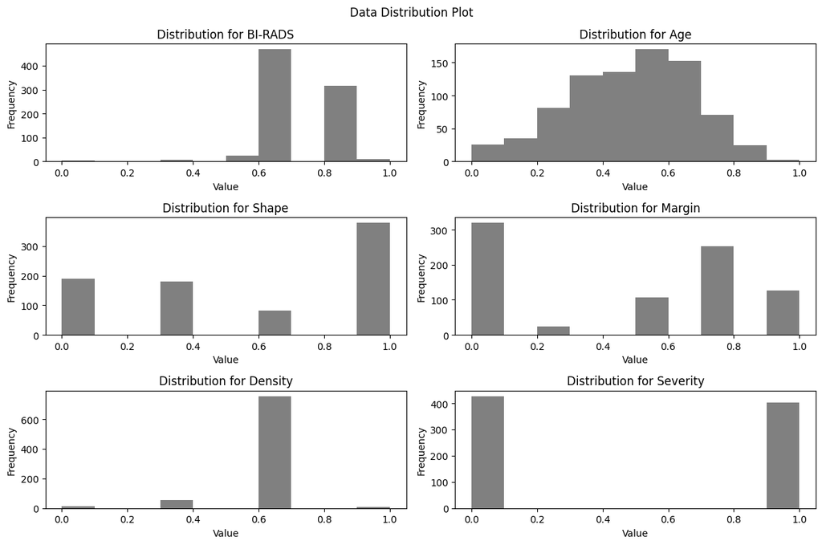

```python
plot_columns(data)
```

```python
X = data.drop(columns = ["Severity"])
y = data["Severity"]
X_train, X_test, y_train, y_test = train_test_split(X, y, test_size=0.2, stratify=y, random_state=42)
feature_names = X_train.columns
```

## Simple Explainable Model - Logistic Regression

### Training

```python
simple_model = LogisticRegression()
simple_model, accuracy, f1, auc, accuracy_test, f1_test, auc_test = use_model(simple_model, X_train, y_train, X_test, y_test)
```

```python
print(f"Train set accuracy: {accuracy}")
print(f"Train set F1: {f1}")
print(f"Train set AUC: {auc}")
print(f"Test set accuracy: {accuracy_test}")
print(f"Test set F1: {f1_test}")
print(f"Test set AUC: {auc_test}")
```

```
Train set accuracy: 0.8298
Train set F1: 0.8285
Train set AUC: 0.9012
Test set accuracy: 0.7952
Test set F1: 0.8111
Test set AUC: 0.8706
```

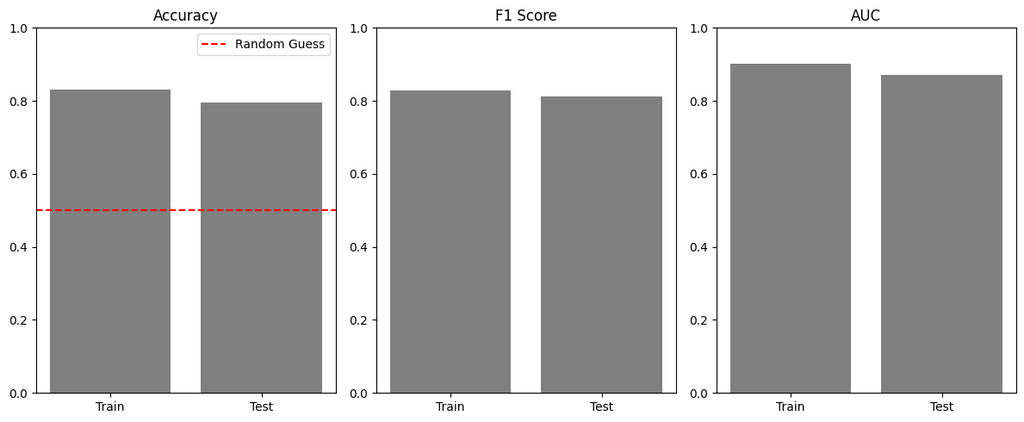

```python
plot_stats(accuracy, accuracy_test, f1, f1_test, auc, auc_test)
```

### 2.1. Explanation of the decisions

```python
coefficients = simple_model.coef_
intercept = simple_model.intercept_

print(f"Coefficients: {coefficients}")
print(f"intercept: {intercept}")
```

```
Coefficients: [[4.00711213 3.09635564 1.67275576 1.48753172 0.46424198]]
intercept: [-6.44428443]
```

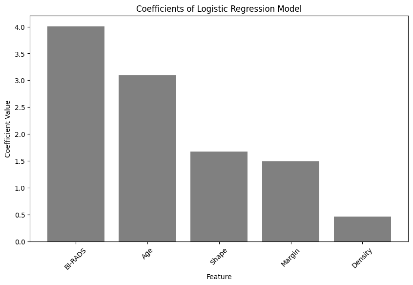

```python
plt.figure(figsize=(10, 6))
plt.bar(range(len(feature_names)), coefficients[0], color="grey")
plt.xticks(range(len(feature_names)), feature_names, rotation=45)
plt.xlabel('Feature')
plt.ylabel('Coefficient Value')
plt.title('Coefficients of Logistic Regression Model')
plt.show()
```

```python
X_test
```

|  | BI-RADS | Age | Shape | Margin | Density |
| --- | --- | --- | --- | --- | --- |
| 162 | 0.833333 | 0.730769 | 1.000000 | 0.75 | 0.666667 |
| 305 | 0.666667 | 0.666667 | 1.000000 | 0.25 | 0.333333 |
| 24 | 0.833333 | 0.538462 | 1.000000 | 0.50 | 0.666667 |
| 667 | 0.666667 | 0.294872 | 0.333333 | 0.25 | 0.666667 |
| 574 | 0.666667 | 0.705128 | 1.000000 | 0.50 | 0.666667 |
| ... | ... | ... | ... | ... | ... |
| 695 | 0.833333 | 0.743590 | 0.000000 | 0.75 | 0.666667 |
| 379 | 0.666667 | 0.589744 | 0.333333 | 0.75 | 0.666667 |
| 208 | 0.666667 | 0.294872 | 0.000000 | 0.00 | 0.666667 |
| 388 | 0.666667 | 0.435897 | 1.000000 | 0.75 | 0.666667 |
| 37 | 0.666667 | 0.461538 | 1.000000 | 0.75 | 0.666667 |

166 rows × 5 columns

```python
test_example_1 = X_test.iloc[0]
test_label_1 = simple_model.predict(X_test.iloc[0].values.reshape(1, -1))[0]
true_label_1 = int(y_test.iloc[0])
test_example_2 = X_test.iloc[1]
test_label_2 = simple_model.predict(X_test.iloc[1].values.reshape(1, -1))[0]
true_label_2 = int(y_test.iloc[1])
test_example_3 = X_test.iloc[9] #taking the 9th example, since we wanted variety with classes
test_label_3 = simple_model.predict(X_test.iloc[9].values.reshape(1, -1))[0]
true_label_3 = int(y_test.iloc[9])
print(f"Test example:\n{test_example_1}")
print(f"\nAssigned Label: {test_label_1}")
print(f"True Label: {true_label_1}")
print("________________________________")
print(f"Test example:\n{test_example_2}")
print(f"\nAssigned Label: {test_label_2}")
print(f"True Label: {true_label_2}")
print("________________________________")
print(f"Test example:\n{test_example_3}")
print(f"\nAssigned Label: {test_label_3}")
print(f"True Label: {true_label_3}")
```

```
Test example:
BI-RADS    0.833333
Age        0.730769
Shape      1.000000
Margin     0.750000
Density    0.666667
Name: 162, dtype: float64

Assigned Label: 1.0
True Label: 1
________________________________
Test example:
BI-RADS    0.666667
Age        0.666667
Shape      1.000000
Margin     0.250000
Density    0.333333
Name: 305, dtype: float64

Assigned Label: 1.0
True Label: 1
________________________________
Test example:
BI-RADS    0.666667
Age        0.282051
Shape      0.333333
Margin     0.000000
Density    0.666667
Name: 462, dtype: float64

Assigned Label: 0.0
True Label: 0
```

#### Explanation of the decision for the selected alternatives:

- test example 1:

High, above average values on every criteria make it a certain member of the positive (severe) class.

- test example 2:

Lower values on less significant features, maximal Shape value which is the third most important coefficient and above average Age indicate positive class assignment.

#### Changes from Theoretical Calculations

```python
get_logistic_regression_changed_prediction(test_example_1, list(X_train.columns), coefficients[0], intercept[0], simple_model)
```

```
Columns in order: ['BI-RADS', 'Age', 'Shape', 'Margin', 'Density']
Original Example: [0.8333, 0.7308, 1.0, 0.75, 0.6667]
New Example Assigned to a different class: [0.2702, 0.7308, 1.0, 0.75, 0.6667]
Minimal Differences: [0.5631, 0.0, 0.0, 0.0, 0.0]
Model's original decision [1.]
Model's new decision: [0.]
```

```python
get_logistic_regression_changed_prediction(test_example_2, list(X_train.columns), coefficients[0], intercept[0], simple_model)
```

```
Columns in order: ['BI-RADS', 'Age', 'Shape', 'Margin', 'Density']
Original Example: [0.6667, 0.6667, 1.0, 0.25, 0.3333]
New Example Assigned to a different class: [0.5439, 0.6667, 1.0, 0.25, 0.3333]
Minimal Differences: [0.1227, 0.0, 0.0, 0.0, 0.0]
Model's original decision [1.]
Model's new decision: [0.]
```

```python
get_logistic_regression_changed_prediction(test_example_3, list(X_train.columns), coefficients[0], intercept[0], simple_model)
```

```
Columns in order: ['BI-RADS', 'Age', 'Shape', 'Margin', 'Density']
Original Example: [0.6667, 0.2821, 0.3333, 0.0, 0.6667]
New Example Assigned to a different class: [1, 0.5074, 0.3333, 0.0, 0.6667]
Minimal Differences: [-0.3333, -0.2253, 0.0, 0.0, 0.0]
Model's original decision [0.]
Model's new decision: [1.]
```

#### Changes from Sampling

```python
change_class_by_sampling(test_example_1, list(X_train.columns), coefficients[0], simple_model)
```

```
Columns in order: ['BI-RADS', 'Age', 'Shape', 'Margin', 'Density']
Original Example: [0.8333, 0.7308, 1.0, 0.75, 0.6667]
New Example Assigned to a different class: [0.2703, 0.7308, 1.0, 0.75, 0.6667]
Minimal Differences: [0.563, 0.0, 0.0, 0.0, 0.0]
Model's original decision 1.0
Model's new decision: 0.0
```

```python
change_class_by_sampling(test_example_2, list(X_train.columns), coefficients[0], simple_model)
```

```
Columns in order: ['BI-RADS', 'Age', 'Shape', 'Margin', 'Density']
Original Example: [0.6667, 0.6667, 1.0, 0.25, 0.3333]
New Example Assigned to a different class: [0.5437, 0.6667, 1.0, 0.25, 0.3333]
Minimal Differences: [0.123, 0.0, 0.0, 0.0, 0.0]
Model's original decision 1.0
Model's new decision: 0.0
```

```python
change_class_by_sampling(test_example_3, list(X_train.columns), coefficients[0], simple_model)
```

```
Columns in order: ['BI-RADS', 'Age', 'Shape', 'Margin', 'Density']
Original Example: [0.6667, 0.2821, 0.3333, 0.0, 0.6667]
New Example Assigned to a different class: [1, 0.5081, 0.3333, 0.0, 0.6667]
Minimal Differences: [-0.3333, -0.226, 0.0, 0.0, 0.0]
Model's original decision 0.0
Model's new decision: 1.0
```

### SHAP explanation

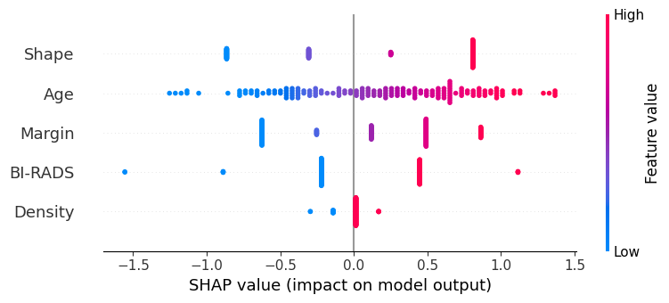

```python
explainer = shap.Explainer(simple_model, X_train)
shap_values = explainer(X_test)
shap.summary_plot(shap_values, X_test, feature_names=X_test.columns)
```

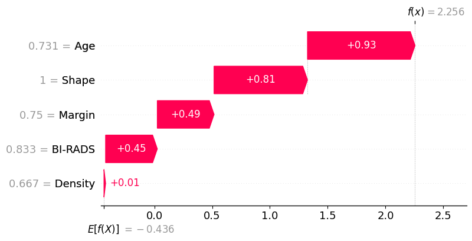

```python
shap.plots.waterfall(shap_values[0])
```

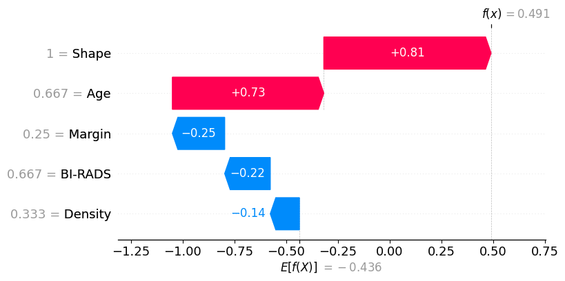

```python
shap.plots.waterfall(shap_values[1])
```

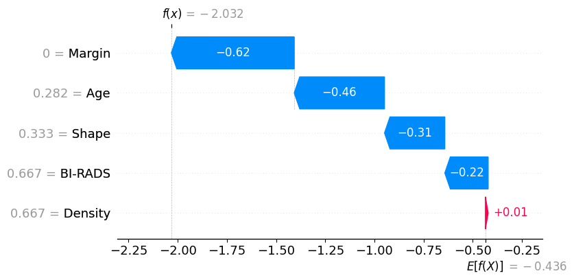

```python
shap.plots.waterfall(shap_values[9])
```

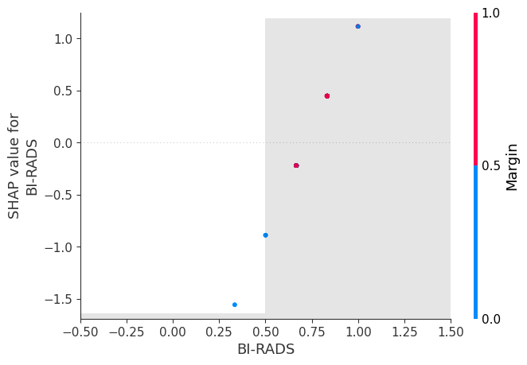

```python
shap.plots.scatter(shap_values[:, "BI-RADS"], color=shap_values)
```

#### Explanation of the decision for the selected alternatives based on SHAP technique:

- test example 1:

SHAP analysis confirms that above average scores in each feature positively contribute to the decision with the Age having the highest influence. This makes sense as Age is the second most important coefficient of the model and the value for this example is high. Second in influence is Shape which is also understandable as this example achieves the highest possible Shape value.

- test example 2:

In this example, low values of low significance features and below average BI-RADS score are offset by maximal Shape value and high Age value.

- test example 3:

Here, the minimal value of Margin has the highest influence on the model's negative decision which is followed by very low Age, a high-importance feature. Slightly above average value of Density does not have almost any influence on the decision.

### Pearson correlation as criteria dependence measure

```python
X.corr(method="pearson")
```

|  | BI-RADS | Age | Shape | Margin | Density |
| --- | --- | --- | --- | --- | --- |
| BI-RADS | 1.000000 | 0.318100 | 0.408349 | 0.422508 | 0.056752 |
| Age | 0.318100 | 1.000000 | 0.380096 | 0.420913 | 0.052417 |
| Shape | 0.408349 | 0.380096 | 1.000000 | 0.738014 | 0.073969 |
| Margin | 0.422508 | 0.420913 | 0.738014 | 1.000000 | 0.124860 |
| Density | 0.056752 | 0.052417 | 0.073969 | 0.124860 | 1.000000 |

### Partial Dependence Plot

```
<sklearn.inspection._plot.partial_dependence.PartialDependenceDisplay at 0x1cbad1e8450>
```

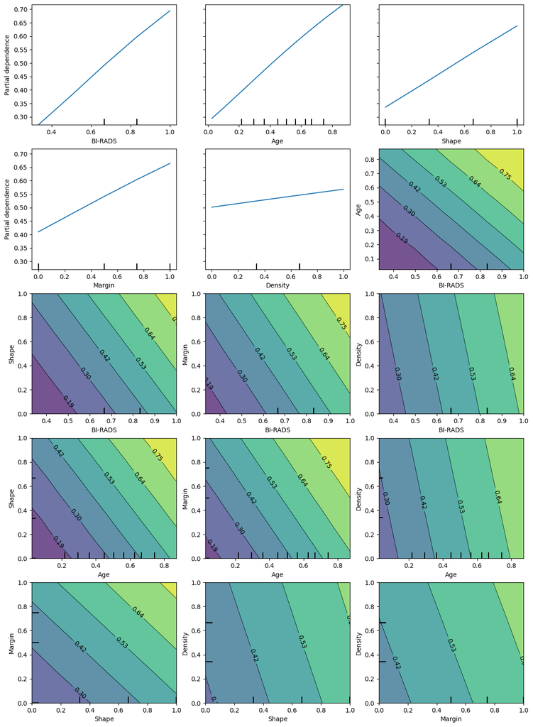

```python
fig, ax = plt.subplots(figsize=(14, 20))
PartialDependenceDisplay.from_estimator(simple_model, X_test, features = [0, 1, 2, 3, 4] + [(a,b) for a in range(5) for b in range(a+1, 5)], ax=ax, response_method="predict_proba")
```

#### Conclusions

Lastly, when looking at the results from both SHAP's summary plot and the achieved weight coefficents, we can see that age, shape and margin can also strongly influence the classification result of our model.

### 2.2. Interpretation of the model

• Based on the parameters obtained, can we say something about the user’s preferences?

According to the model's coefficients, the user prefers high scores of alternatives on all criteria in order to make the positive (malignant) classification. The user should pay high attention to the BI-RADS criteria in particular as it the most influential in the decision.

• What was the influence of the criteria? Are there any criteria that have no effect, or have a decisive influence?

Based on the model's coefficients we can infer that the BI-RADS criteria has more influence than Age which is more important than Shape and Margin which have a notably higher influence than the Density criteria.

• Are there any dependencies between the criteria?

When it comes to analysis of the data itself, there is a positive Pearson correlation between every pair of criteria however most of them are weak (0; 0.3] or moderate (0.3; 0.5] with the exception of Shape and Margin with a strong correlation of 0.74 indicating a possible degree of linear dependency between them.

On the other hand, when analysing the dependencies of the criteria as defined after fitting the model, our logistic regression assumes independence between criteria, as the class assignment is dependent on the weighted sum with the inclusion of the intercept, and the weighted sum model does not model dependencies between criteria.

• What is the nature of the criterion, gain, cost, non-monotonic?

Based on the model's coefficients we can infer that the criteria are of gain type i.e. the increase of a criteria increases the possibility of assignment to the positive (severe) class.

• Whether there are any preference thresholds? Are there any evaluations on criteria that are indifferent in terms of preferences?

• Interpret the model by at least one (Global Surrogate, Partial Dependence Plot, Permutation Feature Importance ...)

According to the Partial Dependence Plot, every criteria increases the probability of assignment of a positive class (severe) with the increase of values with the steepest slope for the BI-RADS and Age criteria. Both Shape and Margin seem to have a significant influence in the decision making process unlike Density which is providing only a slight difference on its own. Similar conclusions can be derived by looking at the joint Partial Dependence Plots with two criteria determining the value of Partial Dependence.

## Interpretable Neural MCDA - ANN-Ch-Constr.

```python
lr = 1e-3
weight_decay = 1e-4
criterion = Regret
num_epochs = 100
```

```
Fitting Neural Network Model
Training Results - Epoch: 1  Avg accuracy: 0.5873 Avg loss: 0.066
Training Results - Epoch: 2  Avg accuracy: 0.6491 Avg loss: 0.0546
Training Results - Epoch: 3  Avg accuracy: 0.7123 Avg loss: 0.0476
Training Results - Epoch: 4  Avg accuracy: 0.741 Avg loss: 0.0433
Training Results - Epoch: 5  Avg accuracy: 0.7681 Avg loss: 0.0406
Training Results - Epoch: 6  Avg accuracy: 0.7666 Avg loss: 0.0383
Training Results - Epoch: 7  Avg accuracy: 0.7741 Avg loss: 0.0362
Training Results - Epoch: 8  Avg accuracy: 0.7756 Avg loss: 0.0342
Training Results - Epoch: 9  Avg accuracy: 0.7786 Avg loss: 0.0323
Training Results - Epoch: 10  Avg accuracy: 0.7831 Avg loss: 0.0304
Training Results - Epoch: 11  Avg accuracy: 0.7892 Avg loss: 0.0287
Training Results - Epoch: 12  Avg accuracy: 0.7937 Avg loss: 0.027
Training Results - Epoch: 13  Avg accuracy: 0.7967 Avg loss: 0.0254
Training Results - Epoch: 14  Avg accuracy: 0.7997 Avg loss: 0.0239
Training Results - Epoch: 15  Avg accuracy: 0.8042 Avg loss: 0.0224
Training Results - Epoch: 16  Avg accuracy: 0.8027 Avg loss: 0.021
Training Results - Epoch: 17  Avg accuracy: 0.8027 Avg loss: 0.0199
Training Results - Epoch: 18  Avg accuracy: 0.8087 Avg loss: 0.0189
Training Results - Epoch: 19  Avg accuracy: 0.8133 Avg loss: 0.018
Training Results - Epoch: 20  Avg accuracy: 0.8102 Avg loss: 0.0173
Training Results - Epoch: 21  Avg accuracy: 0.8087 Avg loss: 0.0167
Training Results - Epoch: 22  Avg accuracy: 0.8027 Avg loss: 0.0161
Training Results - Epoch: 23  Avg accuracy: 0.8057 Avg loss: 0.0156
Training Results - Epoch: 24  Avg accuracy: 0.8057 Avg loss: 0.0152
Training Results - Epoch: 25  Avg accuracy: 0.8027 Avg loss: 0.0148
Training Results - Epoch: 26  Avg accuracy: 0.7982 Avg loss: 0.0144
Training Results - Epoch: 27  Avg accuracy: 0.7967 Avg loss: 0.0141
Training Results - Epoch: 28  Avg accuracy: 0.7952 Avg loss: 0.0139
Training Results - Epoch: 29  Avg accuracy: 0.7952 Avg loss: 0.0136
Training Results - Epoch: 30  Avg accuracy: 0.7967 Avg loss: 0.0135
Training Results - Epoch: 31  Avg accuracy: 0.8012 Avg loss: 0.0133
Training Results - Epoch: 32  Avg accuracy: 0.8012 Avg loss: 0.0131
Training Results - Epoch: 33  Avg accuracy: 0.8027 Avg loss: 0.0129
Training Results - Epoch: 34  Avg accuracy: 0.7982 Avg loss: 0.0128
Training Results - Epoch: 35  Avg accuracy: 0.7937 Avg loss: 0.0127
Training Results - Epoch: 36  Avg accuracy: 0.7982 Avg loss: 0.0125
Training Results - Epoch: 37  Avg accuracy: 0.7937 Avg loss: 0.0123
Training Results - Epoch: 38  Avg accuracy: 0.7937 Avg loss: 0.0122
Training Results - Epoch: 39  Avg accuracy: 0.7937 Avg loss: 0.0121
```

[output cut: 46 more lines]

```
Training Results - Epoch: 86  Avg accuracy: 0.8283 Avg loss: 0.0076
Training Results - Epoch: 87  Avg accuracy: 0.8268 Avg loss: 0.0075
Training Results - Epoch: 88  Avg accuracy: 0.8283 Avg loss: 0.0075
Training Results - Epoch: 89  Avg accuracy: 0.8313 Avg loss: 0.0074
Training Results - Epoch: 90  Avg accuracy: 0.8268 Avg loss: 0.0074
Training Results - Epoch: 91  Avg accuracy: 0.8283 Avg loss: 0.0074
Training Results - Epoch: 92  Avg accuracy: 0.8328 Avg loss: 0.0073
Training Results - Epoch: 93  Avg accuracy: 0.8283 Avg loss: 0.0073
Training Results - Epoch: 94  Avg accuracy: 0.8268 Avg loss: 0.0073
Training Results - Epoch: 95  Avg accuracy: 0.8268 Avg loss: 0.0072
Training Results - Epoch: 96  Avg accuracy: 0.8343 Avg loss: 0.0071
Training Results - Epoch: 97  Avg accuracy: 0.8238 Avg loss: 0.0071
Training Results - Epoch: 98  Avg accuracy: 0.8223 Avg loss: 0.0071
Training Results - Epoch: 99  Avg accuracy: 0.8268 Avg loss: 0.007
Training Results - Epoch: 100  Avg accuracy: 0.8283 Avg loss: 0.007
```

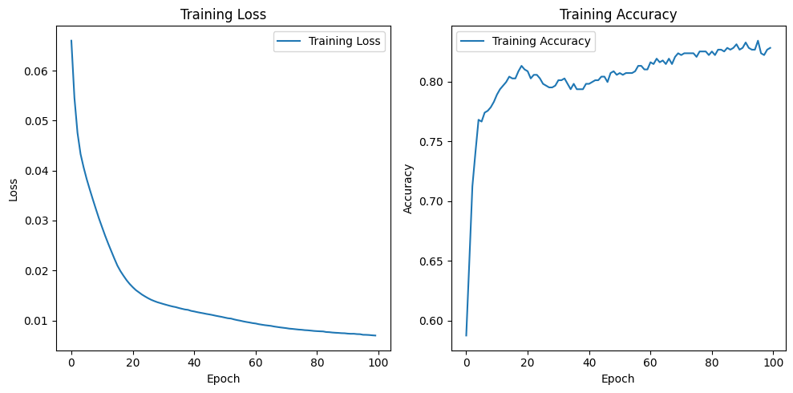

```python
num_criteria = len(X_train.columns)
neural_MCDA_model = ChoquetIntegralConstrained(num_criteria = num_criteria, mobius_transform = morbius_transform)
X_train_processed = neural_MCDA_model.preprocess(X_train.values)
X_test_processed = neural_MCDA_model.preprocess(X_test.values)
optimizer = optim.AdamW(neural_MCDA_model.parameters(), lr=lr, weight_decay=weight_decay)
neural_MCDA_compatible = CompatibleTorchModel(neural_MCDA_model, optimizer, criterion, num_epochs, custom_acc_threshold=True)
neural_MCDA_compatible, accuracy, f1, auc, accuracy_test, f1_test, auc_test = use_model(neural_MCDA_compatible, X_train_processed, y_train.values, X_test_processed, y_test.values)
neural_MCDA_model = neural_MCDA_compatible.model
```

```python
column_names = list(X_test.columns)
new_cols = []
for i in range(len(column_names)):
    for ii in range(i+1, len(column_names)):
        new_cols.append(column_names[i] + "_" + column_names[ii])
column_names += new_cols
```

```python
X_test_processed = pd.DataFrame(X_test_processed, columns=column_names)
X_train_processed = pd.DataFrame(X_train_processed, columns=column_names)

X_test_processed.head(1)
```

|  | BI-RADS | Age | Shape | Margin | Density | BI-RADS_Age | BI-RADS_Shape | BI-RADS_Margin | BI-RADS_Density | Age_Shape | Age_Margin | Age_Density | Shape_Margin | Shape_Density | Margin_Density |
| --- | --- | --- | --- | --- | --- | --- | --- | --- | --- | --- | --- | --- | --- | --- | --- |
| 0 | 0.833333 | 0.730769 | 1.0 | 0.75 | 0.666667 | 0.730769 | 0.833333 | 0.75 | 0.666667 | 0.730769 | 0.730769 | 0.666667 | 0.75 | 0.666667 | 0.666667 |

```python
print(f"Train set accuracy: {accuracy}")
print(f"Train set F1: {f1}")
print(f"Train set AUC: {auc}")
print(f"Test set accuracy: {accuracy_test}")
print(f"Test set F1: {f1_test}")
print(f"Test set AUC: {auc_test}")
```

```
Train set accuracy: 0.8253
Train set F1: 0.8188
Train set AUC: 0.8926
Test set accuracy: 0.7952
Test set F1: 0.8023
Test set AUC: 0.8242
```

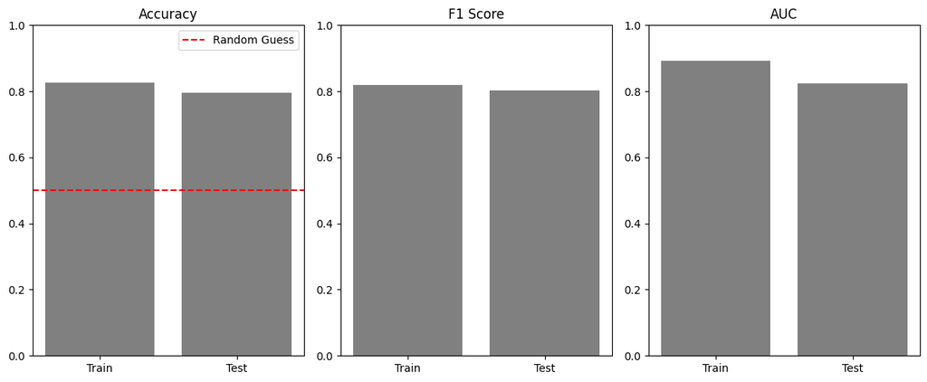

```python
plot_stats(accuracy, accuracy_test, f1, f1_test, auc, auc_test)
```

### 2.1. Explanation of the decisions

```python
weights, interaction_weights, interactions = get_weights_mcda(neural_MCDA_model)
```

```python
print('Criteria weights:')
print(weights)
print()
print('Criteria interactions:')
print(interactions)
```

```
Criteria weights:
[0.52425367 0.34835038 0.07018013 0.17981628 0.3525807 ]

Criteria interactions:
[[ 0.         -0.10519327 -0.0238398  -0.07304518  0.02178689]
 [-0.10519327  0.         -0.02181999 -0.03885446 -0.10582022]
 [-0.0238398  -0.02181999  0.         -0.04995231 -0.00486932]
 [-0.07304518 -0.03885446 -0.04995231  0.         -0.0735735 ]
 [ 0.02178689 -0.10582022 -0.00486932 -0.0735735   0.        ]]
```

```python
combined_weights = list(weights) + list(interaction_weights)
```

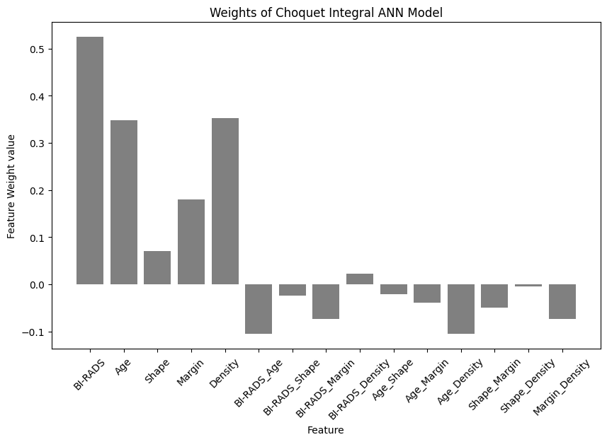

```python
plt.figure(figsize=(10, 6))
plt.bar(range(len(column_names)), combined_weights, color="grey")
plt.xticks(range(len(column_names)), column_names, rotation=45)
plt.xlabel('Feature')
plt.ylabel('Feature Weight value')
plt.title('Weights of Choquet Integral ANN Model')
plt.show()
```

```python
shapley = weights + interactions.sum(0)/2
print('Importance of criterina (Shapley value):')
print(shapley)
```

```
Importance of criterina (Shapley value):
[0.43410799 0.21250641 0.01993942 0.06210355 0.27134262]
```

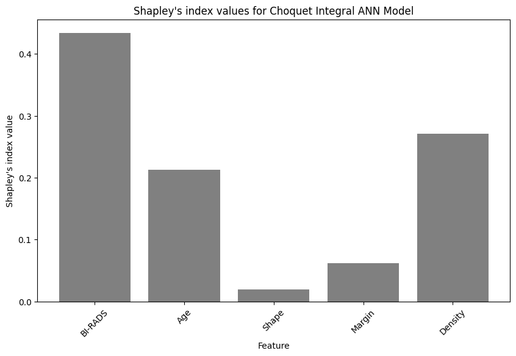

```python
plt.figure(figsize=(10, 6))
plt.bar(range(len(feature_names)), shapley, color="grey")
plt.xticks(range(len(feature_names)), feature_names, rotation=45)
plt.xlabel('Feature')
plt.ylabel("Shapley's index value")
plt.title("Shapley's index values for Choquet Integral ANN Model")
plt.show()
```

```python
test_example_1 = X_test_processed.iloc[0]
test_label_1 = neural_MCDA_compatible.predict(X_test_processed.iloc[0].values.reshape(1, -1))[0]
true_label_1 = int(y_test.iloc[0])
test_example_2 = X_test_processed.iloc[1]
test_label_2 = neural_MCDA_compatible.predict(X_test_processed.iloc[1].values.reshape(1, -1))[0]
true_label_2 = int(y_test.iloc[1])
test_example_3 = X_test_processed.iloc[9] #taking the 9th example, since we wanted variety with classes
test_label_3 = neural_MCDA_compatible.predict(X_test_processed.iloc[9].values.reshape(1, -1))[0]
true_label_3 = int(y_test.iloc[9])
print(f"Test example:\n{test_example_1}")
print(f"\nAssigned Label: {test_label_1}")
print(f"True Label: {true_label_1}")
print("________________________________")
print(f"Test example:\n{test_example_2}")
print(f"\nAssigned Label: {test_label_2}")
print(f"True Label: {true_label_2}")
print("________________________________")
print(f"Test example:\n{test_example_3}")
print(f"\nAssigned Label: {test_label_3}")
print(f"True Label: {true_label_3}")
```

```
Test example:
BI-RADS            0.833333
Age                0.730769
Shape              1.000000
Margin             0.750000
Density            0.666667
BI-RADS_Age        0.730769
BI-RADS_Shape      0.833333
BI-RADS_Margin     0.750000
BI-RADS_Density    0.666667
Age_Shape          0.730769
Age_Margin         0.730769
Age_Density        0.666667
Shape_Margin       0.750000
Shape_Density      0.666667
Margin_Density     0.666667
Name: 0, dtype: float64

Assigned Label: 1
True Label: 1
________________________________
Test example:
BI-RADS            0.666667
Age                0.666667
Shape              1.000000
Margin             0.250000
Density            0.333333
BI-RADS_Age        0.666667
BI-RADS_Shape      0.666667
BI-RADS_Margin     0.250000
BI-RADS_Density    0.333333
Age_Shape          0.666667
Age_Margin         0.250000
Age_Density        0.333333
Shape_Margin       0.250000
Shape_Density      0.333333
Margin_Density     0.250000
Name: 1, dtype: float64

Assigned Label: 0
True Label: 1
________________________________
Test example:
BI-RADS            0.666667
Age                0.282051
Shape              0.333333
Margin             0.000000
Density            0.666667
BI-RADS_Age        0.282051
BI-RADS_Shape      0.333333
BI-RADS_Margin     0.000000
BI-RADS_Density    0.666667
Age_Shape          0.282051
Age_Margin         0.000000
Age_Density        0.282051
Shape_Margin       0.000000
Shape_Density      0.333333
Margin_Density     0.000000
Name: 9, dtype: float64

Assigned Label: 0
True Label: 0
```

#### Plots for model tests using baseline-based attribution algorithms

Baseline: zero-vector

#### References to used methods:

- Integrated Gradients: https://arxiv.org/pdf/1703.01365.pdf - integrating the interpolation difference between noise and input https://distill.pub/2020/attribution-baselines/
- Noise Tunnel: adds a gaussian noise to each input approximating smoothing attribution method with a Gaussian Kernel. https://arxiv.org/abs/1810.03292, https://arxiv.org/abs/1810.03307, https://arxiv.org/abs/1706.03825, https://arxiv.org/abs/1806.10758
- Deep Lift: https://arxiv.org/abs/1704.02685 - comparing the activation of each neuron to its ‘reference activation’ and assigning contribution scores according to the difference https://edwinwenink.github.io/ai-ethics-tool-landscape/tools/deeplift/
- Gradient SHAP: https://github.com/shap/shap#deep-learning-example-with-gradientexplainer-tensorflowkeraspytorch-models - combines ideas from Integrated Gradients, SHAP, and SmoothGrad into a single expected value equation using the entire dataset as background distribution
- Feature Ablation: replacing each input feature with a given baseline / reference, and computing the difference in output
- Guided Backpropagation: https://arxiv.org/abs/1412.6806 - computes the gradient of the target output with respect to the input, but gradients of ReLU functions are overridden so that only non-negative gradients are backpropagated

Code from: https://captum.ai/tutorials/House_Prices_Regression_Interpret

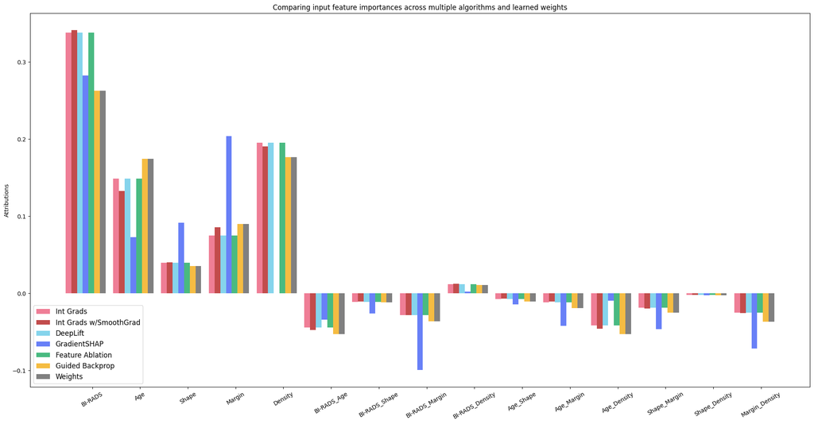

```python
explanation_plots_nn(neural_MCDA_model, X_train_processed, X_test_processed, y_train, y_test, column_names, model_type="mcda")
```

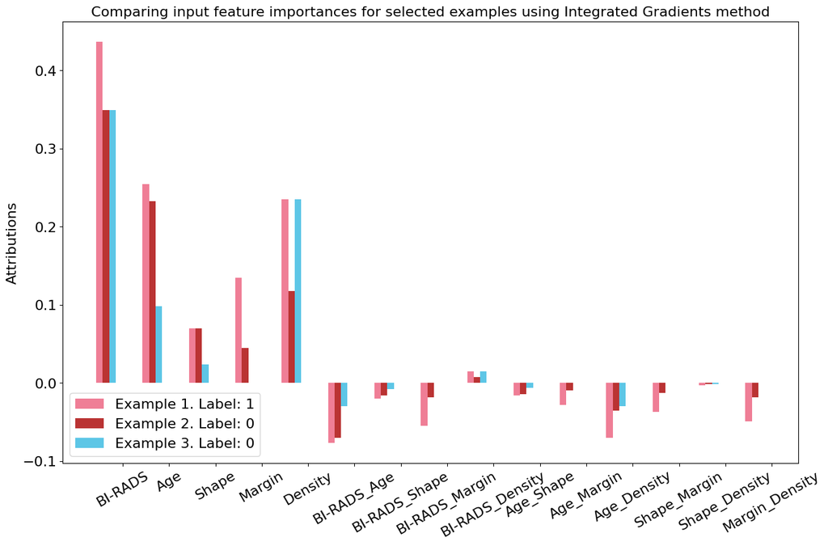

```python
explain_examples(neural_MCDA_model, [test_example_1.values, test_example_2.values, test_example_3.values], column_names,
                 method="integrated_gradients", labels=[test_label_1, test_label_2, test_label_3])
```

#### Explanation of the decision for the selected alternatives:

- test example 1:

Above average values indicate the positive assignment of this example despite the model's weights minimizing the influence of the highest value of the Shape feature.

- test example 2:

In contrary to the logistic regression model, here the influence of the Shape criterion is negligible and therefore the high value of this feature in the example is not able to offset below average values of other attributes, in particular the Density which is the second most important feature. This causes the example to be classified to the negative (malignant class) which is an incorrect class assignment.

- test example 3:

In this example, despite the high Density value, which is considered an important attribute, relatively low scores in remaining attributes, especially Age, indicate an assignment to the negative class.

```python
threshold = float(neural_MCDA_model.threshold_layer.threshold.detach()[0])
print(f"Threshold value for Neural MCDA: {threshold}")
```

```
Threshold value for Neural MCDA: 0.6881592273712158
```

#### Changes from Theoretical Calculations

```python
calculate_smallest_change_MCDA(test_example_1, list(X_train_processed.columns), combined_weights, neural_MCDA_compatible, threshold)
```

```
Columns in order: ['BI-RADS', 'Age', 'Shape', 'Margin', 'Density', 'BI-RADS_Age', 'BI-RADS_Shape', 'BI-RADS_Margin', 'BI-RADS_Density', 'Age_Shape', 'Age_Margin', 'Age_Density', 'Shape_Margin', 'Shape_Density', 'Margin_Density']
Original Example: [0.8333, 0.7308, 1.0, 0.75, 0.6667, 0.7308, 0.8333, 0.75, 0.6667, 0.7308, 0.7308, 0.6667, 0.75, 0.6667, 0.6667]
New Example Assigned to a different class: [0.5732, 0.7308, 1.0, 0.75, 0.6667, 0.5732, 0.5732, 0.5732, 0.5732, 0.7308, 0.7308, 0.6667, 0.75, 0.6667, 0.6667]
Minimal Differences: [0.2602, 0.0, 0.0, 0.0, 0.0, 0.1576, 0.2602, 0.1768, 0.0935, 0.0, 0.0, 0.0, 0.0, 0.0, 0.0]
Model's original decision [1]
Model's new decision: [0]
```

```python
calculate_smallest_change_MCDA(test_example_2, list(X_train_processed.columns), combined_weights, neural_MCDA_compatible, threshold, skip_cols = ["Age", "Margin", "Density"])
```

```
Columns in order: ['BI-RADS', 'Age', 'Shape', 'Margin', 'Density', 'BI-RADS_Age', 'BI-RADS_Shape', 'BI-RADS_Margin', 'BI-RADS_Density', 'Age_Shape', 'Age_Margin', 'Age_Density', 'Shape_Margin', 'Shape_Density', 'Margin_Density']
Original Example: [0.6667, 0.6667, 1.0, 0.25, 0.3333, 0.6667, 0.6667, 0.25, 0.3333, 0.6667, 0.25, 0.3333, 0.25, 0.3333, 0.25]
New Example Assigned to a different class: [0.7942, 0.6667, 1.0, 0.25, 0.3333, 0.6667, 0.7942, 0.25, 0.3333, 0.6667, 0.25, 0.3333, 0.25, 0.3333, 0.25]
Minimal Differences: [-0.1275, 0.0, 0.0, 0.0, 0.0, 0.0, -0.1275, 0.0, 0.0, 0.0, 0.0, 0.0, 0.0, 0.0, 0.0]
Model's original decision [0]
Model's new decision: [1]
```

```python
calculate_smallest_change_MCDA(test_example_3, list(X_train_processed.columns), combined_weights, neural_MCDA_compatible, threshold, skip_cols = ["Age", "Margin", "Shape", "Density"])
```

```
Columns in order: ['BI-RADS', 'Age', 'Shape', 'Margin', 'Density', 'BI-RADS_Age', 'BI-RADS_Shape', 'BI-RADS_Margin', 'BI-RADS_Density', 'Age_Shape', 'Age_Margin', 'Age_Density', 'Shape_Margin', 'Shape_Density', 'Margin_Density']
Original Example: [0.6667, 0.2821, 0.3333, 0.0, 0.6667, 0.2821, 0.3333, 0.0, 0.6667, 0.2821, 0.0, 0.2821, 0.0, 0.3333, 0.0]
New Example Assigned to a different class: [0.75, 0.2821, 0.3333, 0.0, 0.6667, 0.2821, 0.3333, 0.0, 0.6667, 0.2821, 0.0, 0.2821, 0.0, 0.3333, 0.0]
Minimal Differences: [-0.0833, 0.0, 0.0, 0.0, 0.0, 0.0, 0.0, 0.0, 0.0, 0.0, 0.0, 0.0, 0.0, 0.0, 0.0]
Model's original decision [0]
Model's new decision: [1]
```

#### Changes from Sampling

```python
change_class_by_sampling_MCDA(test_example_1, list(X_train_processed.columns), combined_weights, neural_MCDA_compatible)
```

```
Columns in order: ['BI-RADS', 'Age', 'Shape', 'Margin', 'Density', 'BI-RADS_Age', 'BI-RADS_Shape', 'BI-RADS_Margin', 'BI-RADS_Density', 'Age_Shape', 'Age_Margin', 'Age_Density', 'Shape_Margin', 'Shape_Density', 'Margin_Density']
Original Example: [0.8333, 0.7308, 1.0, 0.75, 0.6667, 0.7308, 0.8333, 0.75, 0.6667, 0.7308, 0.7308, 0.6667, 0.75, 0.6667, 0.6667]
New Example Assigned to a different class: [0.5753, 0.7308, 1.0, 0.75, 0.6667, 0.5753, 0.5753, 0.5753, 0.5753, 0.7308, 0.7308, 0.6667, 0.75, 0.6667, 0.6667]
Minimal Differences: [0.258, 0.0, 0.0, 0.0, 0.0, 0.1554, 0.258, 0.1747, 0.0913, 0.0, 0.0, 0.0, 0.0, 0.0, 0.0]
Model's original decision 1
Model's new decision: 0
```

```python
change_class_by_sampling_MCDA(test_example_2, list(X_train_processed.columns), combined_weights, neural_MCDA_compatible)
```

```
Columns in order: ['BI-RADS', 'Age', 'Shape', 'Margin', 'Density', 'BI-RADS_Age', 'BI-RADS_Shape', 'BI-RADS_Margin', 'BI-RADS_Density', 'Age_Shape', 'Age_Margin', 'Age_Density', 'Shape_Margin', 'Shape_Density', 'Margin_Density']
Original Example: [0.6667, 0.6667, 1.0, 0.25, 0.3333, 0.6667, 0.6667, 0.25, 0.3333, 0.6667, 0.25, 0.3333, 0.25, 0.3333, 0.25]
New Example Assigned to a different class: [0.7927, 0.6667, 1.0, 0.25, 0.3333, 0.6667, 0.7927, 0.25, 0.3333, 0.6667, 0.25, 0.3333, 0.25, 0.3333, 0.25]
Minimal Differences: [-0.126, 0.0, 0.0, 0.0, 0.0, 0.0, -0.126, 0.0, 0.0, 0.0, 0.0, 0.0, 0.0, 0.0, 0.0]
Model's original decision 0
Model's new decision: 1
```

```python
change_class_by_sampling_MCDA(test_example_3, list(X_train_processed.columns), combined_weights, neural_MCDA_compatible)
```

```
Columns in order: ['BI-RADS', 'Age', 'Shape', 'Margin', 'Density', 'BI-RADS_Age', 'BI-RADS_Shape', 'BI-RADS_Margin', 'BI-RADS_Density', 'Age_Shape', 'Age_Margin', 'Age_Density', 'Shape_Margin', 'Shape_Density', 'Margin_Density']
Original Example: [0.6667, 0.2821, 0.3333, 0.0, 0.6667, 0.2821, 0.3333, 0.0, 0.6667, 0.2821, 0.0, 0.2821, 0.0, 0.3333, 0.0]
New Example Assigned to a different class: [0.7487, 0.2821, 0.3333, 0.0, 0.6667, 0.2821, 0.3333, 0.0, 0.6667, 0.2821, 0.0, 0.2821, 0.0, 0.3333, 0.0]
Minimal Differences: [-0.082, 0.0, 0.0, 0.0, 0.0, 0.0, 0.0, 0.0, 0.0, 0.0, 0.0, 0.0, 0.0, 0.0, 0.0]
Model's original decision 0
Model's new decision: 1
```

### SHAP explanation

```python
explainer = shap.Explainer(neural_MCDA_compatible.predict, X_train_processed.values, feature_names=column_names)

# masker = shap.maskers.Independent(X_test_processed, 10)
# shap_values = explainer(masker.data)

shap_values = explainer(X_test_processed) # takes > 1hr
```

```
Permutation explainer: 167it [1:11:22, 25.80s/it]
```

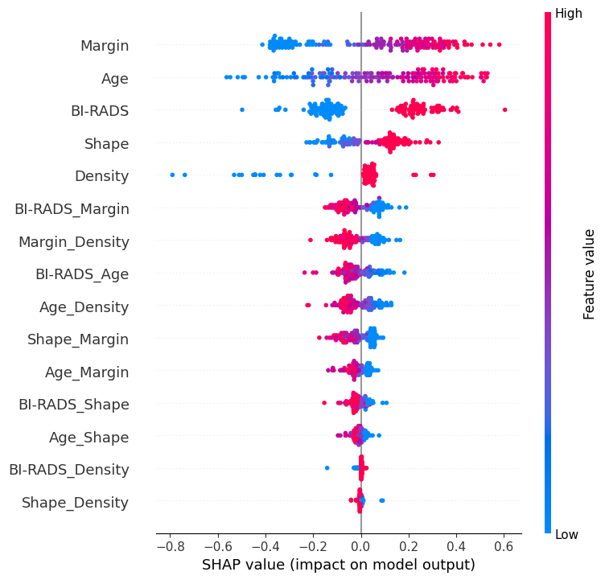

```python
# shap.summary_plot(shap_values, masker.data, feature_names=column_names)
shap.summary_plot(shap_values, X_test_processed.values, feature_names=column_names)
```

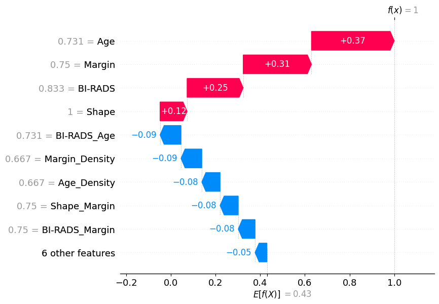

```python
shap.plots.waterfall(shap_values[0])
```

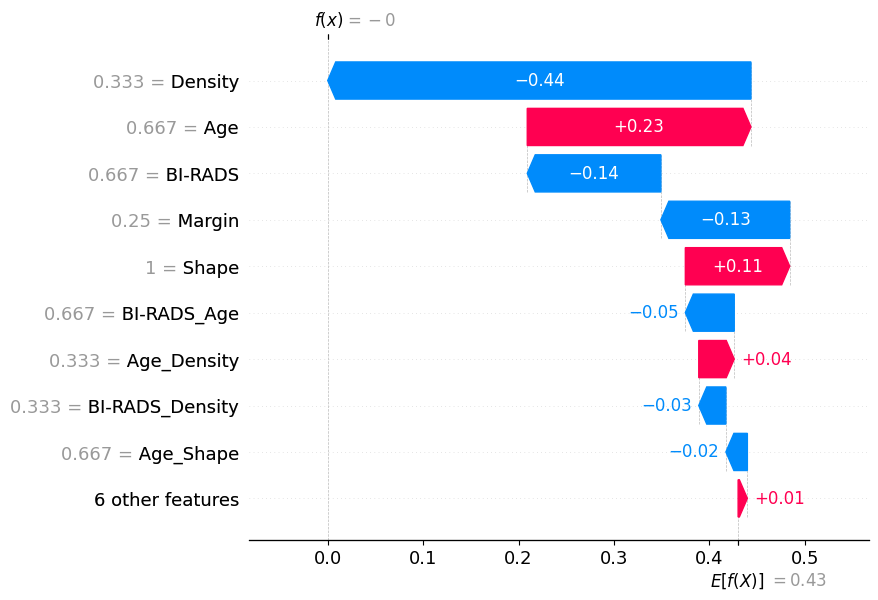

```python
shap.plots.waterfall(shap_values[1])
```

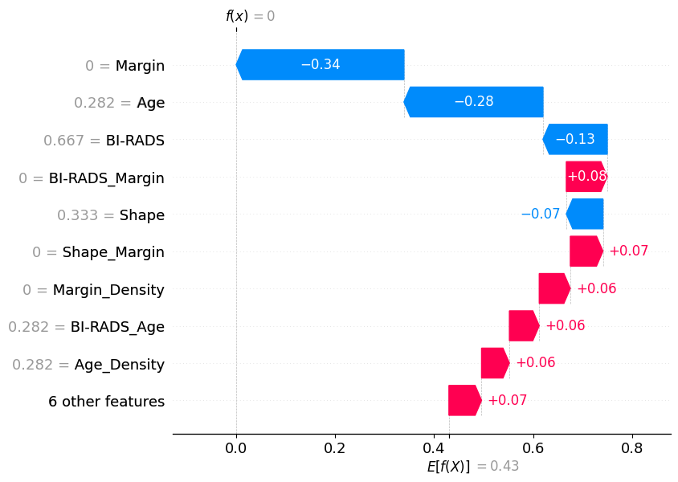

```python
shap.plots.waterfall(shap_values[9])
```

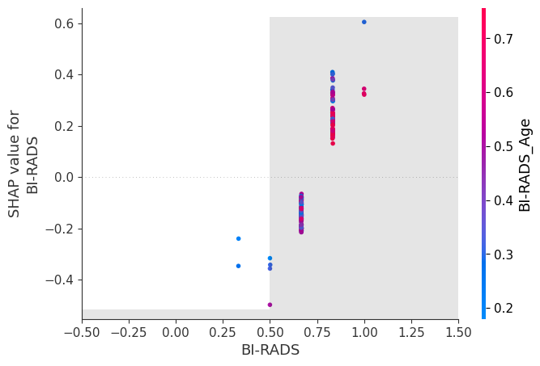

```python
shap.plots.scatter(shap_values[:, "BI-RADS"], color=shap_values)
```

#### Explanation of the decision for the selected alternatives based on SHAP technique:

- test example 1:

SHAP analysis confirms that above average scores in each feature positively contribute to the decision with the Age having the highest influence. Despite the low weight importance, Margin also has a considerable impact due to its high value. Joint criteria negatively influence the decision but do not manage to change class attribution.

- test example 2:

According to the analysis, a very low value of Density had a major impact on the assignment. Second in influence is Age which is an important attribute. Despite its maximal value of 1, Shape does not impact the decision in a significant way due to its low weight importance.

- test example 3:

For this example, the minimal value of Margin and very low Age decisively contribute the negative class assignment. Low weights of joint criteria features do not manage to change the decision.

### Partial Dependence Plot

```
<sklearn.inspection._plot.partial_dependence.PartialDependenceDisplay at 0x2c7aba29f90>
```

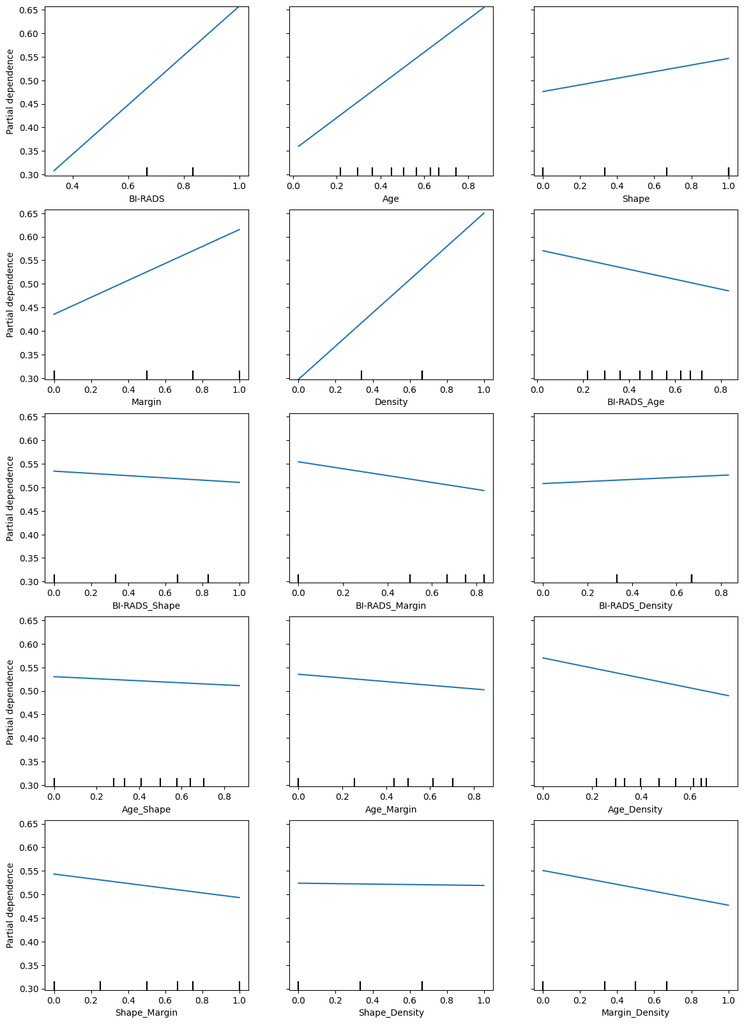

```python
fig, ax = plt.subplots(figsize=(14, 20))
PartialDependenceDisplay.from_estimator(neural_MCDA_compatible, X_test_processed.values, features = list(range(15)), ax=ax, response_method="predict_proba", feature_names=column_names)
```

#### Conclusions

According to the calculations, the model chose the BI-RADS attribute as the most influential in the process of decision making. Other important features are the Age and Density. The Shape attribute seems to have almost negligible effect. Most criteria interactions have negative weights indicating redundancy. Magnitude of criteria interaction weights are relatively low.

The model performs slightly worse than logistic regression on all metrics other than test set accurracy for which the resulting score is identical.

### 2.2. Interpretation of the model

• Based on the parameters obtained, can we say something about the user’s preferences?

Increase of score on any criteria other than Shape, which has a very low influence on the decision, increases the probability of assignment to the positive (severe) class. The model prefers high BI-RADS, Density and Age scores with BI-RADS being the most significant.

• What was the influence of the criteria? Are there any criteria that have no effect, or have a decisive influence?

Based on the weights, we can say that the most influential criterion is BI-RADS which has a decisive influence with both the Age and Density being significant factors in the decision making process. On the other hand, Shape seems to have negligible impact on the choice of class.

• Are there any dependencies between the criteria?

Dependency between the criteria can be seen on the weights present in the interactions between the criteria per the choquel integral model. However, the interactions seem generally weak with and most of the interactios show redundency between criteria.

• What is the nature of the criterion, gain, cost, non-monotonic?

Criteria are of gain type as their increase increases the probability of assignment to the positive (severe) class.

• Whether there are any preference thresholds? Are there any evaluations on criteria that are indifferent in terms of preferences?

Preference threhsold as given by the neural MCDA model is given in the context of the choquet integral, and in this case the value of the threshold is: 0.6882

• Interpret the model by at least one (Global Surrogate, Partial Dependence Plot, Permutation Feature Importance ...)

According to the Partial Dependence Plot, the most influential criteria are: BI-RADS, Density and Age. Shape and Margin seem to be less important and their slopes are similar to the steepest negative slopes of Age_Density and Margin_Density criteria interaction features.

## ANN Model

Warning! For reproducibility, please restart and run only the code necessary for this (ANN model) section to work.

```python
lr = 1e-3
weight_decay = 1e-4
criterion = nn.BCELoss()
num_epochs = 100
```

```
Fitting Neural Network Model
Training Results - Epoch: 1  Avg accuracy: 0.4849 Avg loss: 0.6927
Training Results - Epoch: 2  Avg accuracy: 0.5151 Avg loss: 0.6768
Training Results - Epoch: 3  Avg accuracy: 0.756 Avg loss: 0.6418
Training Results - Epoch: 4  Avg accuracy: 0.7907 Avg loss: 0.5773
Training Results - Epoch: 5  Avg accuracy: 0.7952 Avg loss: 0.5128
Training Results - Epoch: 6  Avg accuracy: 0.7982 Avg loss: 0.4849
Training Results - Epoch: 7  Avg accuracy: 0.7831 Avg loss: 0.4705
Training Results - Epoch: 8  Avg accuracy: 0.8027 Avg loss: 0.4621
Training Results - Epoch: 9  Avg accuracy: 0.8042 Avg loss: 0.4557
Training Results - Epoch: 10  Avg accuracy: 0.7997 Avg loss: 0.451
Training Results - Epoch: 11  Avg accuracy: 0.8087 Avg loss: 0.4518
Training Results - Epoch: 12  Avg accuracy: 0.8087 Avg loss: 0.4387
Training Results - Epoch: 13  Avg accuracy: 0.8193 Avg loss: 0.4367
Training Results - Epoch: 14  Avg accuracy: 0.8072 Avg loss: 0.4364
Training Results - Epoch: 15  Avg accuracy: 0.8148 Avg loss: 0.4318
Training Results - Epoch: 16  Avg accuracy: 0.8042 Avg loss: 0.4257
Training Results - Epoch: 17  Avg accuracy: 0.8117 Avg loss: 0.4201
Training Results - Epoch: 18  Avg accuracy: 0.8163 Avg loss: 0.4198
Training Results - Epoch: 19  Avg accuracy: 0.8193 Avg loss: 0.4146
Training Results - Epoch: 20  Avg accuracy: 0.8253 Avg loss: 0.4141
Training Results - Epoch: 21  Avg accuracy: 0.8238 Avg loss: 0.4209
Training Results - Epoch: 22  Avg accuracy: 0.8223 Avg loss: 0.4085
Training Results - Epoch: 23  Avg accuracy: 0.8238 Avg loss: 0.4044
Training Results - Epoch: 24  Avg accuracy: 0.8328 Avg loss: 0.4011
Training Results - Epoch: 25  Avg accuracy: 0.8223 Avg loss: 0.4028
Training Results - Epoch: 26  Avg accuracy: 0.8298 Avg loss: 0.4021
Training Results - Epoch: 27  Avg accuracy: 0.8328 Avg loss: 0.3991
Training Results - Epoch: 28  Avg accuracy: 0.8268 Avg loss: 0.3984
Training Results - Epoch: 29  Avg accuracy: 0.8133 Avg loss: 0.4293
Training Results - Epoch: 30  Avg accuracy: 0.8133 Avg loss: 0.4256
Training Results - Epoch: 31  Avg accuracy: 0.8253 Avg loss: 0.3935
Training Results - Epoch: 32  Avg accuracy: 0.8313 Avg loss: 0.3918
Training Results - Epoch: 33  Avg accuracy: 0.8238 Avg loss: 0.4014
Training Results - Epoch: 34  Avg accuracy: 0.8268 Avg loss: 0.3902
Training Results - Epoch: 35  Avg accuracy: 0.8283 Avg loss: 0.3877
Training Results - Epoch: 36  Avg accuracy: 0.8253 Avg loss: 0.3915
Training Results - Epoch: 37  Avg accuracy: 0.8298 Avg loss: 0.3873
Training Results - Epoch: 38  Avg accuracy: 0.8328 Avg loss: 0.3834
Training Results - Epoch: 39  Avg accuracy: 0.8283 Avg loss: 0.3846
```

[output cut: 46 more lines]

```
Training Results - Epoch: 86  Avg accuracy: 0.8434 Avg loss: 0.3586
Training Results - Epoch: 87  Avg accuracy: 0.8328 Avg loss: 0.3558
Training Results - Epoch: 88  Avg accuracy: 0.8464 Avg loss: 0.3568
Training Results - Epoch: 89  Avg accuracy: 0.8389 Avg loss: 0.3606
Training Results - Epoch: 90  Avg accuracy: 0.8434 Avg loss: 0.3573
Training Results - Epoch: 91  Avg accuracy: 0.8509 Avg loss: 0.3561
Training Results - Epoch: 92  Avg accuracy: 0.8449 Avg loss: 0.3574
Training Results - Epoch: 93  Avg accuracy: 0.8419 Avg loss: 0.3568
Training Results - Epoch: 94  Avg accuracy: 0.8494 Avg loss: 0.3609
Training Results - Epoch: 95  Avg accuracy: 0.8554 Avg loss: 0.3549
Training Results - Epoch: 96  Avg accuracy: 0.8449 Avg loss: 0.3608
Training Results - Epoch: 97  Avg accuracy: 0.8524 Avg loss: 0.3549
Training Results - Epoch: 98  Avg accuracy: 0.8358 Avg loss: 0.362
Training Results - Epoch: 99  Avg accuracy: 0.8373 Avg loss: 0.3632
Training Results - Epoch: 100  Avg accuracy: 0.8569 Avg loss: 0.353
```

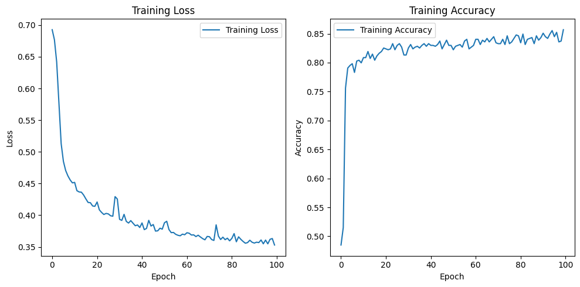

```python
ann_model = ANN(len(X_train.columns), 1)
optimizer = optim.AdamW(ann_model.parameters(), lr=lr, weight_decay=weight_decay)
torch_model = CompatibleTorchModel(ann_model, optimizer, criterion, num_epochs)
torch_model, accuracy, f1, auc, accuracy_test, f1_test, auc_test = use_model(torch_model, X_train.values, y_train.values, X_test.values, y_test.values)
ann_model = torch_model.model
```

```python
print(f"Train set accuracy: {accuracy}")
print(f"Train set F1: {f1}")
print(f"Train set AUC: {auc}")
print(f"Test set accuracy: {accuracy_test}")
print(f"Test set F1: {f1_test}")
print(f"Test set AUC: {auc_test}")
```

```
Train set accuracy: 0.8373
Train set F1: 0.8444
Train set AUC: 0.9201
Test set accuracy: 0.8072
Test set F1: 0.8298
Test set AUC: 0.8913
```

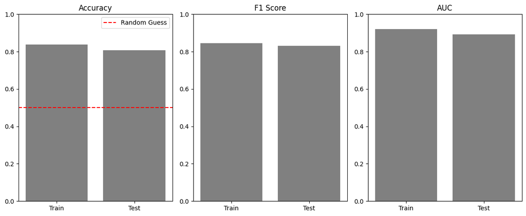

```python
plot_stats(accuracy, accuracy_test, f1, f1_test, auc, auc_test)
```

### 2.1. Explanation of the decisions

```python
test_example_1 = X_test.iloc[0]
test_label_1 = torch_model.predict(X_test.iloc[0].values.reshape(1, -1))[0]
true_label_1 = int(y_test.iloc[0])
test_example_2 = X_test.iloc[1]
test_label_2 = torch_model.predict(X_test.iloc[1].values.reshape(1, -1))[0]
true_label_2 = int(y_test.iloc[1])
test_example_3 = X_test.iloc[9]
test_label_3 = torch_model.predict(X_test.iloc[9].values.reshape(1, -1))[0]
true_label_3 = int(y_test.iloc[9])
print(f"Test example:\n{test_example_1}")
print(f"\nAssigned Label: {test_label_1}")
print(f"True Label: {true_label_1}")
print("________________________________")
print(f"Test example:\n{test_example_2}")
print(f"\nAssigned Label: {test_label_2}")
print(f"True Label: {true_label_2}")
print("________________________________")
print(f"Test example:\n{test_example_3}")
print(f"\nAssigned Label: {test_label_3}")
print(f"True Label: {true_label_3}")
```

```
Test example:
BI-RADS    0.833333
Age        0.730769
Shape      1.000000
Margin     0.750000
Density    0.666667
Name: 162, dtype: float64

Assigned Label: 1
True Label: 1
________________________________
Test example:
BI-RADS    0.666667
Age        0.666667
Shape      1.000000
Margin     0.250000
Density    0.333333
Name: 305, dtype: float64

Assigned Label: 1
True Label: 1
________________________________
Test example:
BI-RADS    0.666667
Age        0.282051
Shape      0.333333
Margin     0.000000
Density    0.666667
Name: 462, dtype: float64

Assigned Label: 0
True Label: 0
```

#### Plots for model tests using baseline-based attribution algorithms

Baseline: zero-vector

#### References to used methods:

- Integrated Gradients: https://arxiv.org/pdf/1703.01365.pdf - integrating the interpolation difference between noise and input https://distill.pub/2020/attribution-baselines/
- Noise Tunnel: adds a gaussian noise to each input approximating smoothing attribution method with a Gaussian Kernel. https://arxiv.org/abs/1810.03292, https://arxiv.org/abs/1810.03307, https://arxiv.org/abs/1706.03825, https://arxiv.org/abs/1806.10758
- Deep Lift: https://arxiv.org/abs/1704.02685 - comparing the activation of each neuron to its ‘reference activation’ and assigning contribution scores according to the difference https://edwinwenink.github.io/ai-ethics-tool-landscape/tools/deeplift/
- Gradient SHAP: https://github.com/shap/shap#deep-learning-example-with-gradientexplainer-tensorflowkeraspytorch-models - combines ideas from Integrated Gradients, SHAP, and SmoothGrad into a single expected value equation using the entire dataset as background distribution
- Feature Ablation: replacing each input feature with a given baseline / reference, and computing the difference in output
- Guided Backpropagation: https://arxiv.org/abs/1412.6806 - computes the gradient of the target output with respect to the input, but gradients of ReLU functions are overridden so that only non-negative gradients are backpropagated

Code from: https://captum.ai/tutorials/House_Prices_Regression_Interpret

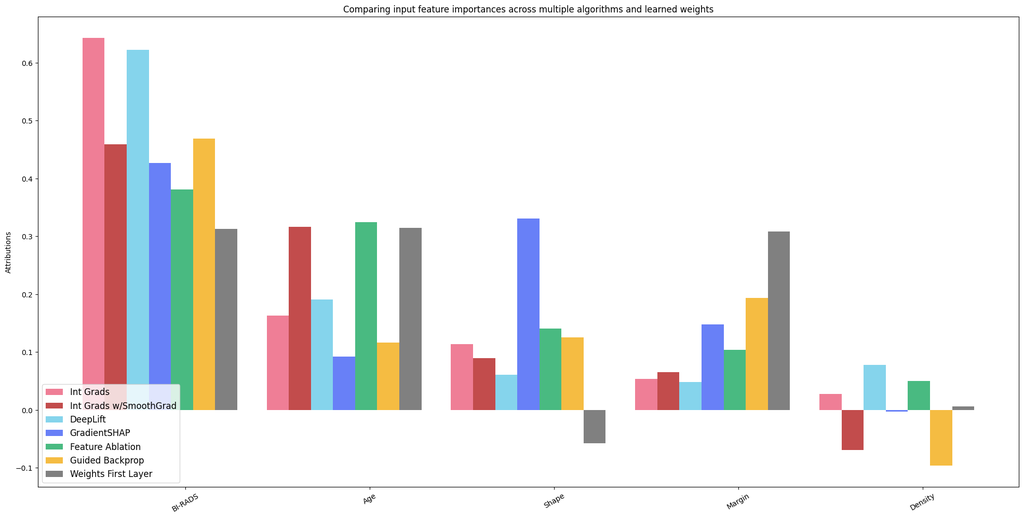

```python
explanation_plots_nn(ann_model, X_train, X_test, y_train, y_test, feature_names)
```

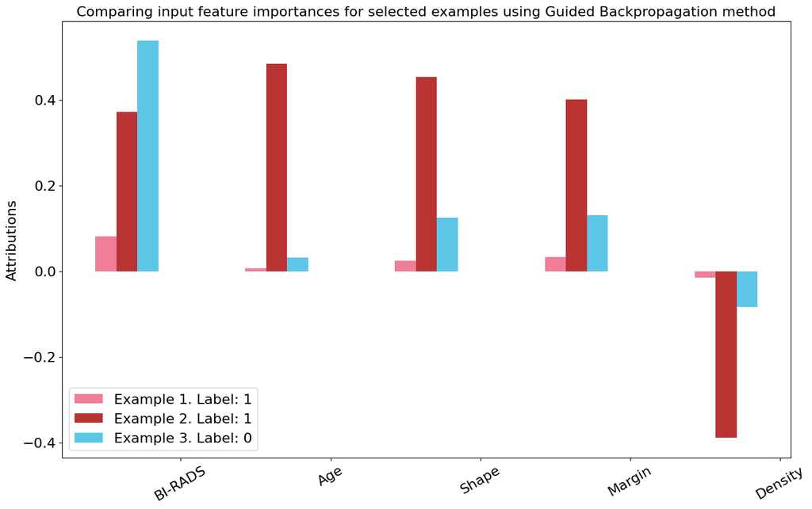

```python
explain_examples(ann_model, [test_example_1.values, test_example_2.values, test_example_3.values], feature_names,
                 method="guided_backprop", labels=[test_label_1, test_label_2, test_label_3])
```

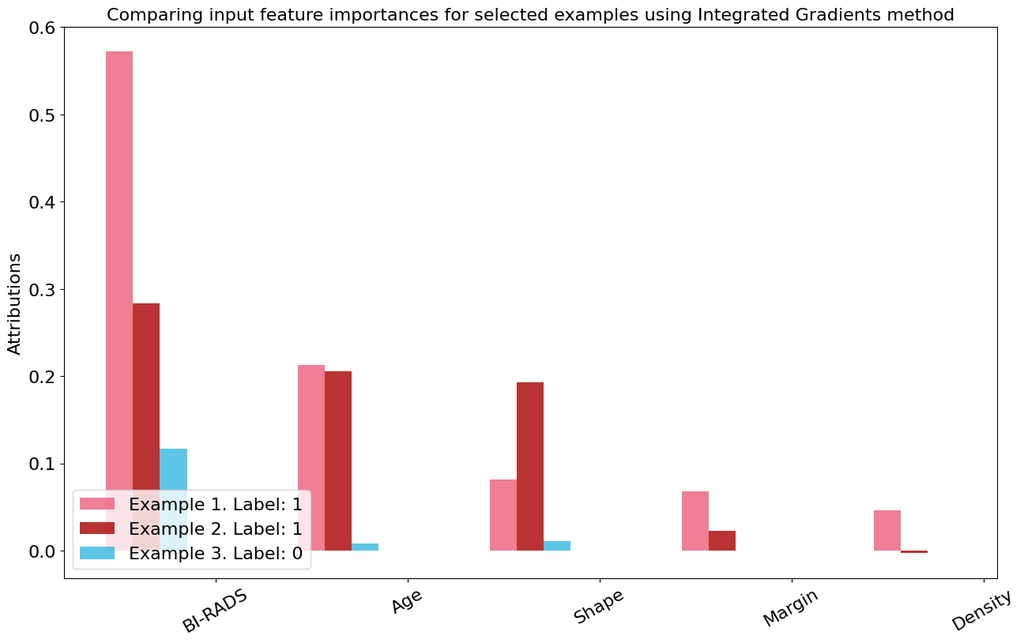

```python
explain_examples(ann_model, [test_example_1.values, test_example_2.values, test_example_3.values], feature_names,
                 method="integrated_gradients", labels=[test_label_1, test_label_2, test_label_3])
```

#### Explanation of the decision for the selected alternatives:

*Significance of criteria is based on the test-set-aggregated and individual results from feature importance algorithms presented above.*

- test example 1:

High, above average values on every criteria make it a certain member of the positive (severe) class.

- test example 2:

Lower values on less significant features, maximal Shape value which is an influential coefficient and above average Age indicate positive class assignment. This example seems to be very close to being assigned to the opposite class as the most significant feature BI-RADS is not high.

According to the Integrated Gradients test, Margin and Density is not important for the model in context of this example which would make sense considering that low values for these attributes could assign this example to the other, incorrect class.

- test example 3:

Below average BI-RADS value, minimal Margin and low Shape score cause negative (malignant) class assignment, this is shown by the Guided Backpropagation test where Margin has the second most important contributor to the decision.

#### Changes from Theoretical Calculations

```python
change_class_by_guided_gradient(test_example_1, list(X_train.columns), ann_model)
```

```
Columns in order: ['BI-RADS', 'Age', 'Shape', 'Margin', 'Density']
Original Example: [0.8333, 0.7308, 1.0, 0.75, 0.6667]
New Example Assigned to a different class: [0.6333, 0.5308, 0.8, 0.55, 0.5667]
Minimal Differences: [0.2, 0.2, 0.2, 0.2, 0.1]
Model's original decision 1
Model's new decision: 0
```

```python
change_class_by_guided_gradient(test_example_2, list(X_train.columns), ann_model)
```

```
Columns in order: ['BI-RADS', 'Age', 'Shape', 'Margin', 'Density']
Original Example: [0.6667, 0.6667, 1.0, 0.25, 0.3333]
New Example Assigned to a different class: [0.6267, 0.6267, 0.96, 0.21, 0.3333]
Minimal Differences: [0.04, 0.04, 0.04, 0.04, -0.0]
Model's original decision 1
Model's new decision: 0
```

```python
change_class_by_guided_gradient(test_example_3, list(X_train.columns), ann_model)
```

```
Columns in order: ['BI-RADS', 'Age', 'Shape', 'Margin', 'Density']
Original Example: [0.6667, 0.2821, 0.3333, 0.0, 0.6667]
New Example Assigned to a different class: [0.7467, 0.3621, 0.4133, 0.08, 0.6067]
Minimal Differences: [-0.08, -0.08, -0.08, -0.08, 0.06]
Model's original decision 0
Model's new decision: 1
```

#### Changes from Sampling

```python
nn_change_class_by_sampling(test_example_1, list(X_train.columns), torch_model)
```

```
Columns in order: ['BI-RADS', 'Age', 'Shape', 'Margin', 'Density']
Original Example: [0.8333, 0.7308, 1.0, 0.75, 0.6667]
New Example Assigned to a different class: [0.5993, 0.4968, 1.0, 0.75, 0.6667]
Differences: [0.234 0.234 0.    0.    0.   ]
Model's original decision 1
Model's new decision: 0
```

```python
nn_change_class_by_sampling(test_example_2, list(X_train.columns), torch_model)
```

```
Columns in order: ['BI-RADS', 'Age', 'Shape', 'Margin', 'Density']
Original Example: [0.6667, 0.6667, 1.0, 0.25, 0.3333]
New Example Assigned to a different class: [0.6057, 0.6057, 1.0, 0.25, 0.3333]
Differences: [0.061 0.061 0.    0.    0.   ]
Model's original decision 1
Model's new decision: 0
```

```python
nn_change_class_by_sampling(test_example_3, list(X_train.columns), torch_model)
```

```
Columns in order: ['BI-RADS', 'Age', 'Shape', 'Margin', 'Density']
Original Example: [0.6667, 0.2821, 0.3333, 0.0, 0.6667]
New Example Assigned to a different class: [0.7867, 0.2821, 0.3333, 0.0, 0.6667]
Differences: [-0.12  0.    0.    0.    0.  ]
Model's original decision 0
Model's new decision: 1
```

### SHAP explanation

```python
explainer = shap.Explainer(torch_model.predict, X_train.values, feature_names=X_train.columns)

shap_values = explainer(X_test)
```

```
Exact explainer: 167it [00:25,  4.39it/s]
```

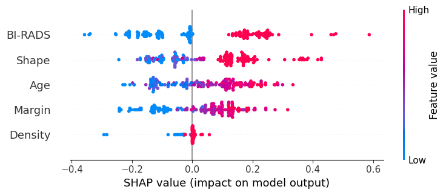

```python
shap.summary_plot(shap_values, X_test, feature_names=X_train.columns)
```

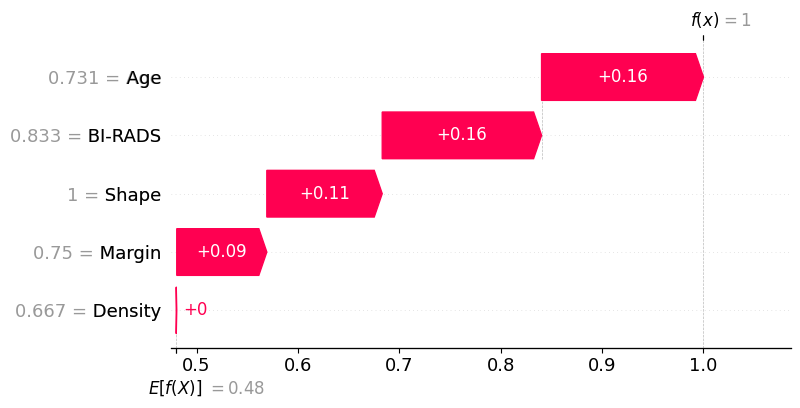

```python
shap.plots.waterfall(shap_values[0])
```

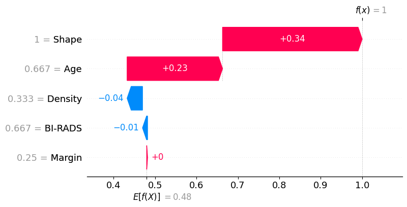

```python
shap.plots.waterfall(shap_values[1])
```

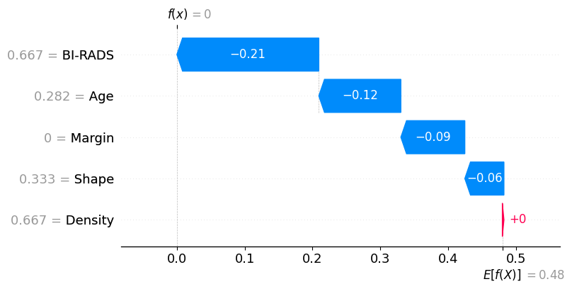

```python
shap.plots.waterfall(shap_values[9])
```

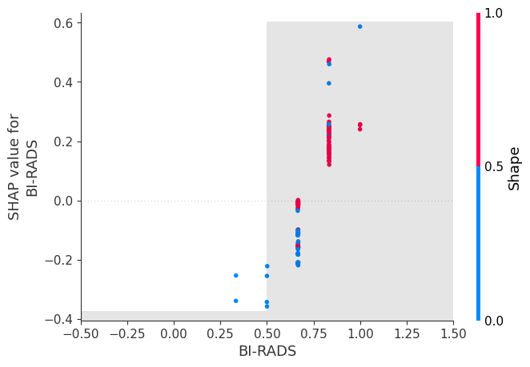

```python
shap.plots.scatter(shap_values[:, "BI-RADS"], color=shap_values)
```

#### Explanation of the decision for the selected alternatives based on SHAP technique:

- test example 1:

SHAP analysis confirms that above average scores in each feature positively contribute to the decision with the Age and BI-RADS having the highest influence. This makes sense as Age is the second most important coefficient of the model and the value for this example is high. Third in influence is Shape which is also understandable as this example achieves the highest possible Shape value.

- test example 2:

In this example, low values of low significance features and below average BI-RADS score are offset by maximal Shape value and high Age value. Low influence of Margin and Density attributes align with the Integrated Gradients test result.

- test example 3:

The below average BI-RADS value has the highest influence on the decision with the remaining attributes also supporting the negative decision. Influence of higher values of Density is seemingly turned off for this example. This situation aligns with the Integrated Gradients test results although the influence of Margin feature does not.

### Partial Dependence Plot

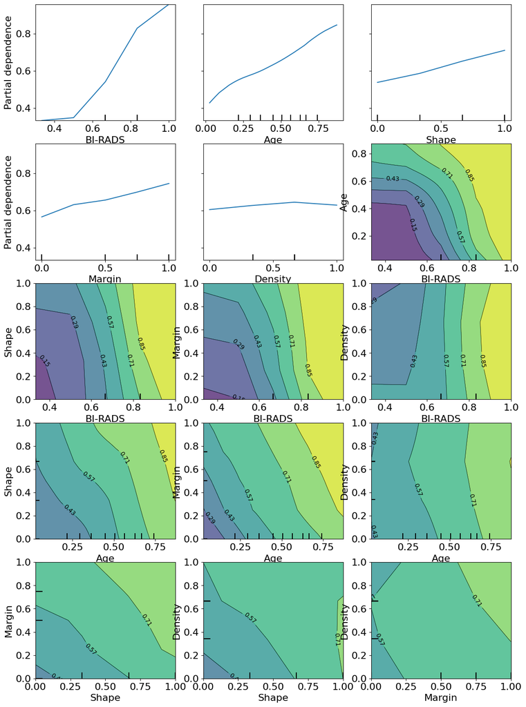

```python
fig, ax = plt.subplots(figsize=(14, 20))
pdp = PartialDependenceDisplay.from_estimator(torch_model, X_test.values, features = [0, 1, 2, 3, 4] + [(a,b) for a in range(5) for b in range(a+1, 5)],
                                         ax=ax, response_method="predict_proba", feature_names=X_train.columns)
```

#### Conclusions

Based on the performed analysis, we can say that the BI-RADS score is the most influential feature in the model's decision making. Age and Shape attributes seem to also have a significant influence with Age being more important according to the Partial Dependence Plot. Shape and Margin attributes seem to be the least significant in the presented measures. All features have a positive impact on the classification - the increase of value increase the probability of assignment to the positive (severe) class. The least significant attribute is Density which is reflected both by the feature importance methods and the Partial Dependency Plot. Performance of the model is slightly better than that of Logistic Regression model on all shown metrics.

### 2.2. Interpretation of the model

• Based on the parameters obtained, can we say something about the user’s preferences?

Based on the feature importance methods we can say that the BI-RADS is the most important criteria in the decision making process followed by Age, Shape and Margin with similar importances. The Density attribute seems to be not influential in the process.

• What was the influence of the criteria? Are there any criteria that have no effect, or have a decisive influence?

All criteria have a positive influence on the decision - higher values increase probablility of assgnment to the positive (severe) class. BI-RADS seems to be the most decisive criteria although Age is also an important attribute. On the other hand, Density seems to have close to no effect - a fact which is reflected by all tests to some extent.

• Are there any dependencies between the criteria?

According to the Partial Dependence Plot, most criteria interact positively with each other in the decision making process. BI-RADS score has a decisive influence in the process for most criteria combinations. We can see that low-importance features e.g. Density and Margin do not impact the process much even when combined.

• What is the nature of the criterion, gain, cost, non-monotonic?

The criteria are of gain type, they have a positive influence on the decision higher values increase probablility of assgnment to the positive (severe) class.

Density could possibly be a non monotonic criterion as shown on the Partial Dependence Plot although the influence of this change is minimal.

• Whether there are any preference thresholds? Are there any evaluations on criteria that are indifferent in terms of preferences?

Using the Partial Dependence plot we can derive preference thresholds in form of values for which average marginal effect on the prediction passes 0.5. These thresholds for each attribute are as follows:

- BI-RADS: 0.6
- Age: 0.15
- Shape: 0.0 (always above 0.5)
- Margin: 0.0 (always above 0.5)
- Density: 0.0 (always above 0.5)

In terms of criteria indifference, we can see that the Density attribute has negligible influence on the decision regardless of value.

• Interpret the model by at least one (Global Surrogate, Partial Dependence Plot, Permutation Feature Importance ...)

According to the Partial Dependence Plot, the most influential is the BI-RADS attribute followed by the Age feature. Both Shape and Margin seem to have a similar influence on the decision. The Density attribute seems to have very little effect on the classification, the plot slightly decreases above 0.6 values which is not expected however might be negligible in the process.